# Introduction to R (Mid-Term Assignment)

Rakesh Babu Gedela(E21016) & Satish Srinivas(E21015)

22 June 2021

**Introduction:** ##A dataset of a company is given to analyse the Attrition rate with respect to the variables like ‘Age’, ‘MonthlyIncome’,DistancefromHome’ etc. for each employee.

**Objective:** we have to identify the factors affecting attrition.

## Look into summary of data

```r
setwd("C:\\Users\\satish\\Downloads")  #set the working directory
data <- read.csv("attrition.csv")

summary(data)
```

```
##       Age          Attrition      BusinessTravel      Department
##  Min.   :18.00   Min.   :0.0000   Length:1470        Length:1470
##  1st Qu.:30.00   1st Qu.:0.0000   Class :character   Class :character
##  Median :36.00   Median :0.0000   Mode  :character   Mode  :character
##  Mean   :36.92   Mean   :0.1612
##  3rd Qu.:43.00   3rd Qu.:0.0000
##  Max.   :60.00   Max.   :1.0000
##  EducationField     EnvironmentSatisfaction    Gender          JobInvolvement
##  Length:1470        Min.   :1.000           Length:1470        Min.   :1.00
##  Class :character   1st Qu.:2.000           Class :character   1st Qu.:2.00
##  Mode  :character   Median :3.000           Mode  :character   Median :3.00
##                     Mean   :2.722                              Mean   :2.73
##                     3rd Qu.:4.000                              3rd Qu.:3.00
##                     Max.   :4.000                              Max.   :4.00
##     JobLevel     JobSatisfaction MaritalStatus      MonthlyIncome
##  Min.   :1.000   Min.   :1.000   Length:1470        Min.   : 1009
##  1st Qu.:1.000   1st Qu.:2.000   Class :character   1st Qu.: 2911
##  Median :2.000   Median :3.000   Mode  :character   Median : 4919
##  Mean   :2.064   Mean   :2.729                      Mean   : 6503
##  3rd Qu.:3.000   3rd Qu.:4.000                      3rd Qu.: 8379
##  Max.   :5.000   Max.   :4.000                      Max.   :19999
##    OverTime         TotalWorkingYears WorkLifeBalance YearsAtCompany
##  Length:1470        Min.   : 0.00     Min.   :1.000   Min.   : 0.000
##  Class :character   1st Qu.: 6.00     1st Qu.:2.000   1st Qu.: 3.000
##  Mode  :character   Median :10.00     Median :3.000   Median : 5.000
##                     Mean   :11.28     Mean   :2.761   Mean   : 7.008
##                     3rd Qu.:15.00     3rd Qu.:3.000   3rd Qu.: 9.000
##                     Max.   :40.00     Max.   :4.000   Max.   :40.000
##  YearsInCurrentRole YearsSinceLastPromotion YearsWithCurrManager
##  Min.   : 0.000     Min.   : 0.000          Min.   : 0.000
##  1st Qu.: 2.000     1st Qu.: 0.000          1st Qu.: 2.000
##  Median : 3.000     Median : 1.000          Median : 3.000
##  Mean   : 4.229     Mean   : 2.188          Mean   : 4.123
##  3rd Qu.: 7.000     3rd Qu.: 3.000          3rd Qu.: 7.000
##  Max.   :18.000     Max.   :15.000          Max.   :17.000
##  DistanceFromHome
##  Min.   : 1.000
##  1st Qu.: 2.000
##  Median : 7.000
##  Mean   : 9.193
##  3rd Qu.:14.000
##  Max.   :29.000
```

```r
dim(data)
```

```
## [1] 1470   20
```

```r
str(data)
```

```
## 'data.frame':    1470 obs. of  20 variables:
##  $ Age                    : int  41 49 37 33 27 32 59 30 38 36 ...
##  $ Attrition              : int  1 0 1 0 0 0 0 0 0 0 ...
##  $ BusinessTravel         : chr  "Travel_Rarely" "Travel_Frequently" "Travel_Rarely" "Travel_Frequently" ...
##  $ Department             : chr  "Sales" "Research & Development" "Research & Development" "Research & Development" ...
##  $ EducationField         : chr  "Life Sciences" "Life Sciences" "Other" "Life Sciences" ...
##  $ EnvironmentSatisfaction: int  2 3 4 4 1 4 3 4 4 3 ...
##  $ Gender                 : chr  "Female" "Male" "Male" "Female" ...
##  $ JobInvolvement         : int  3 2 2 3 3 3 4 3 2 3 ...
##  $ JobLevel               : int  2 2 1 1 1 1 1 1 3 2 ...
##  $ JobSatisfaction        : int  4 2 3 3 2 4 1 3 3 3 ...
##  $ MaritalStatus          : chr  "Single" "Married" "Single" "Married" ...
##  $ MonthlyIncome          : int  5993 5130 2090 2909 3468 3068 2670 2693 9526 5237 ...
##  $ OverTime               : chr  "Yes" "No" "Yes" "Yes" ...
##  $ TotalWorkingYears      : int  8 10 7 8 6 8 12 1 10 17 ...
##  $ WorkLifeBalance        : int  1 3 3 3 3 2 2 3 3 2 ...
##  $ YearsAtCompany         : int  6 10 0 8 2 7 1 1 9 7 ...
##  $ YearsInCurrentRole     : int  4 7 0 7 2 7 0 0 7 7 ...
##  $ YearsSinceLastPromotion: int  0 1 0 3 2 3 0 0 1 7 ...
##  $ YearsWithCurrManager   : int  5 7 0 0 2 6 0 0 8 7 ...
##  $ DistanceFromHome       : int  1 8 2 3 2 2 3 24 23 27 ...
```

### We can see there are 20 columns and 1470 rows in total

- *Hypothesis 1:* ### Age of the employee: can have some impact on the attrition. Studies and surveys have shown that employees are more likely to switch jobs during the early stages of their career. So it may be possible that higher the age, less likely the attrition.

*code:*

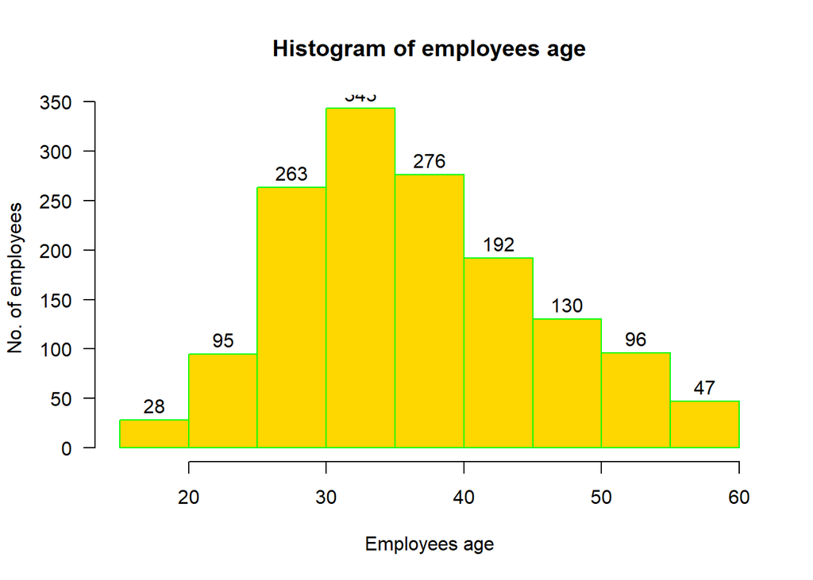

```r
hist(data$Age,
     main = "Histogram of employees age", # title of the histogram
     xlab="Employees age",
     ylab = "No. of employees",
     col = "gold",
     border = "green",
     las = 1,
     labels = T
#     breaks = seq(min(houses$sqft_living), max(houses$sqft_living), length.out = 101)
     # size of each bin. we are giving a sequence of numbers with the the range in min to max of
     # the data and divided into total of 100 bins. used when we want to control number
     # and size of intervals in data (bins) and focus on those distributions

)
```

## creating a column ‘Age bin’ in the range (20,60 with 20 as bin size) to see

## the relation bewtween attrition vs Age.

```r
data8 <- data
data8$Agebin <-cut(data$Age,labels=seq(20,40,20),
                            breaks = seq(20,60,20))

# % attrition  vs non-attrition - Agebin
# table indicates the conditional probablity ie P(attrition status| the Age bin).
round(prop.table(table(data8$Attrition,data8$Agebin), margin=2),2)*100
```

```
##
##     20 40
##   0 83 89
##   1 17 11
```

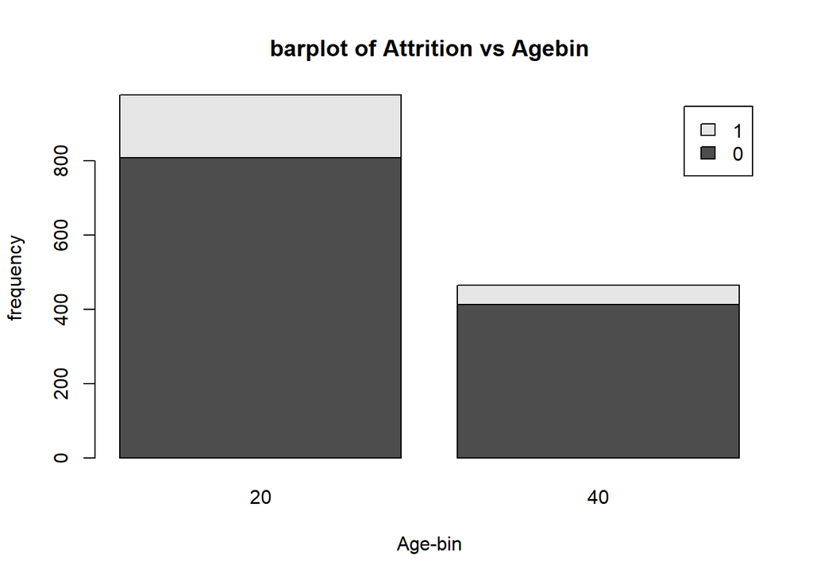

```r
barplot(table(data8$Attrition, data8$Agebin),
        legend.text = T,
        xlab= 'Age-bin',
        ylab='frequency',
        main= 'barplot of Attrition vs Agebin')
```

## We can see higher the age, lower the attrition, supporting the hypothesis

- *Hypothesis 2:*

### Business travel: represents how frequently an employee has to travel for the job. Though there may be a factor of tiredness due to frequent travel, employee would mostly know about the travel frequency before joining the job, so this may have negligible impact on the attrition of the employee

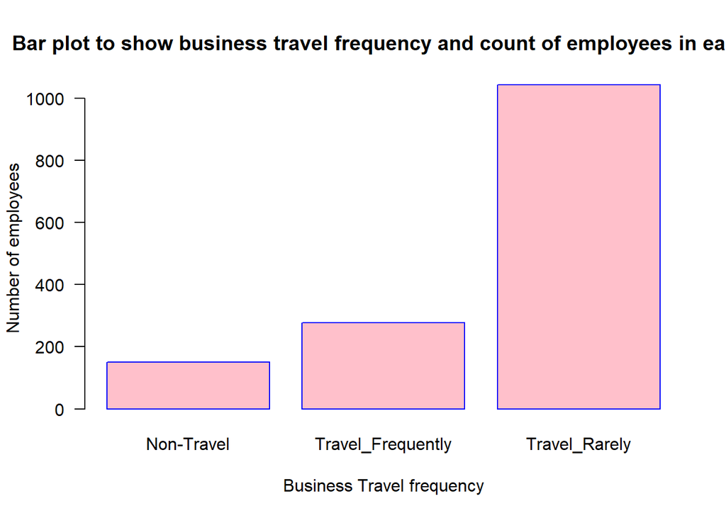

```r
barplot(table(data$BusinessTravel ), # table used to get counts of each group
        main = "Bar plot to show business travel frequency and count of employees in each.", # Title we want
                # to give to the bar plot
        xlab = "Business Travel frequency", # Used to give label to the x axis
        ylab = "Number of employees", # Used to give label to the y axis
        col = "pink", # used to give colour to the bars for visual appeal
        border = 'blue', # used to denote border and outliers colour to distinguish and
        # visual appeal
        horiz = F, # boolean to denote whether we want the bars to be horizontal
        las = 1, # see both y-axis and x axis values horizontally, used when we want to see the
        # axes values clearly and avoid overlap with other values
        )
```

## This is a categorical column. We can see that majority employees travel rarely

```r
data$BusinessTravel <- as.factor(data$BusinessTravel)
```

## Bivariate: Attrition grouped by business travel

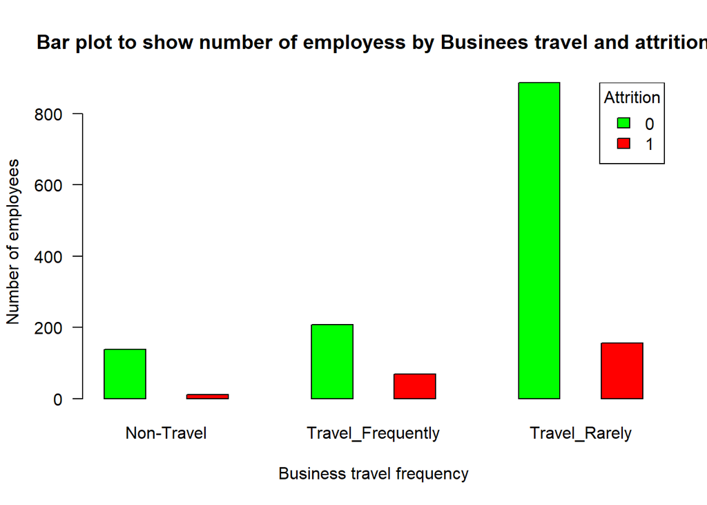

```r
barplot(table(data$Attrition, data$BusinessTravel),
        col = c("green", "red"), # used to indicate the colours we want
              # for each of the bars in the group
        beside = T,   # used to indicate when we want the bars to be besides each other in the groups
        main = "Bar plot to show number of employess by Businees travel and attrition",
        xlab = "Business travel frequency",
        ylab = "Number of employees",
        las = 1,
        space = c(1,2), # specify number of spaces within and between groups of bars, used when
                #we want to add spaces between bars for clarity
        )

# use legend function to add more info to the bar plot (more useful than legend.text in barplot)
## new arguments explored: position, values, fill, title
legend("topright", # specify position where we want to add legend in the plot
       c("0", "1"), # specify values for which we want to add legend
       fill = c("green","red"), # specify colour we want to fill for
              # each corresponding legend value
       title = "Attrition" # specify the tile of the legend
       )
```

### We can see that highest count of attrition is in case of rare travel and least in non- travel

### But we may need to get proportion of attriton in each group as the number of employees in each group is different

```r
round(prop.table(table(data$Attrition, data$BusinessTravel), 2), 2) * 100
```

```
##
##     Non-Travel Travel_Frequently Travel_Rarely
##   0         92                75            85
##   1          8                25            15
```

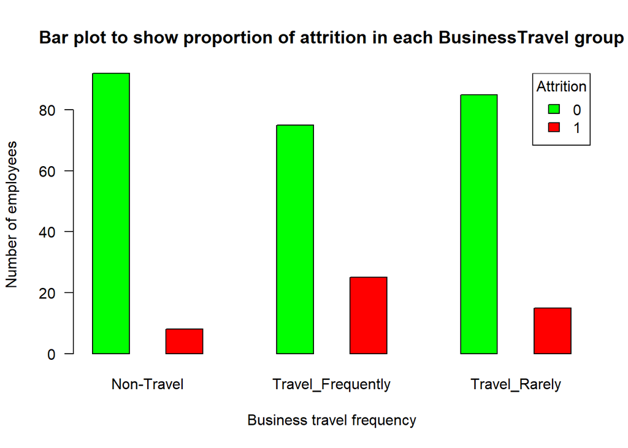

```r
barplot(round(prop.table(table(data$Attrition, data$BusinessTravel), 2), 2) * 100,
        col = c("green", "red"), # used to indicate the colours we want
              # for each of the bars in the group
        beside = T,   # used to indicate when we want the bars to be besides each other in the groups
        main = "Bar plot to show proportion of attrition in each BusinessTravel group",
        xlab = "Business travel frequency",
        ylab = "Number of employees",
        las = 1,
        space = c(1,2), # specify number of spaces within and between groups of bars, used when
                #we want to add spaces between bars for clarity
        )

# use legend function to add more info to the bar plot (more useful than legend.text in barplot)
## new arguments explored: position, values, fill, title
legend("topright", # specify position where we want to add legend in the plot
       c("0", "1"), # specify values for which we want to add legend
       fill = c("green","red"), # specify colour we want to fill for
              # each corresponding legend value
       title = "Attrition" # specify the tile of the legend
       )
```

## We can see that as the business travel increases, the attrition rate also increases. This rejects our hypothesis.

- *Hypothesis 3:*

### Department the employee belongs to: it determines the type of work and field of the employee’s job, but this may not have a big impact on the attrition as each type of job comes with pros and cons, so attrition rate in each Department is likely to be the same

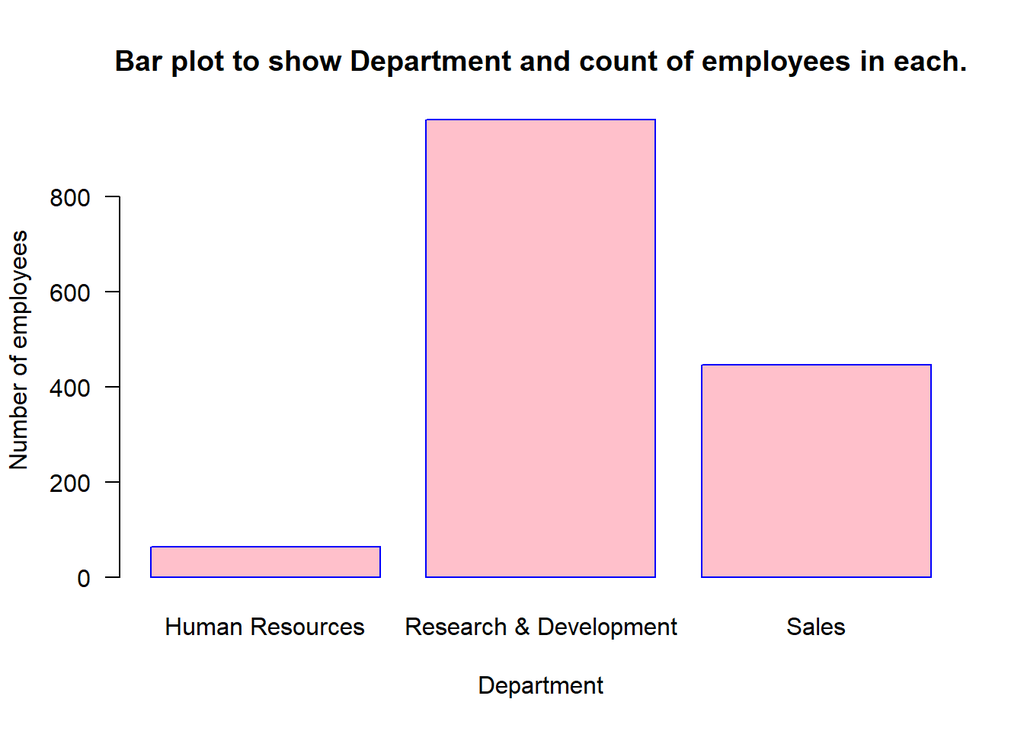

```r
barplot(table(data$Department ), # table used to get counts of each group
        main = "Bar plot to show Department and count of employees in each.", # Title we want
                # to give to the bar plot
        xlab = "Department", # Used to give label to the x axis
        ylab = "Number of employees", # Used to give label to the y axis
        col = "pink", # used to give colour to the bars for visual appeal
        border = 'blue', # used to denote border and outliers colour to distinguish and
        # visual appeal
        horiz = F, # boolean to denote whether we want the bars to be horizontal
        las = 1, # see both y-axis and x axis values horizontally, used when we want to see the
        # axes values clearly and avoid overlap with other values
        )
```

## R and D has most employees and HR has least

## This is a categorical column. So we can convert its type

```r
data$Department <- as.factor(data$Department)
```

## Bivariate: Attrition grouped by Department

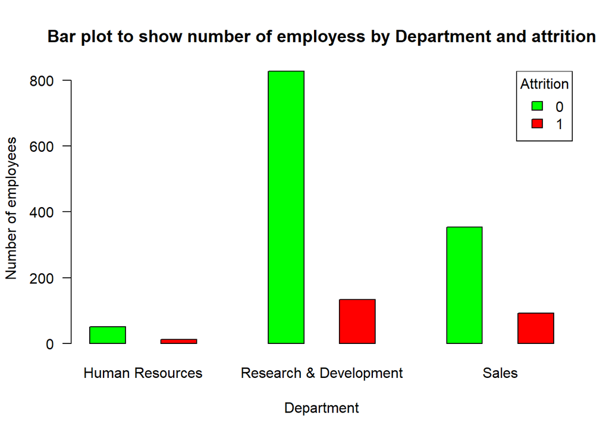

```r
barplot(table(data$Attrition, data$Department),
        col = c("green", "red"), # used to indicate the colours we want
              # for each of the bars in the group
        beside = T,   # used to indicate when we want the bars to be besides each other in the groups
        main = "Bar plot to show number of employess by Department and attrition",
        xlab = "Department",
        ylab = "Number of employees",
        las = 1,
        space = c(1,2), # specify number of spaces within and between groups of bars, used when
                #we want to add spaces between bars for clarity
        )

# use legend function to add more info to the bar plot (more useful than legend.text in barplot)
## new arguments explored: position, values, fill, title
legend("topright", # specify position where we want to add legend in the plot
       c("0", "1"), # specify values for which we want to add legend
       fill = c("green","red"), # specify colour we want to fill for
              # each corresponding legend value
       title = "Attrition" # specify the tile of the legend
       )
```

### We can see that highest count of attrition is in case of R&D and least in HR

### But we may need to get proportion of attriton in each group as the number of employees in each group is different

## Proportion table (Attrition | feature)

```r
round(prop.table(table(data$Attrition, data$Department), 2), 2) * 100
```

```
##
##     Human Resources Research & Development Sales
##   0              81                     86    79
##   1              19                     14    21
```

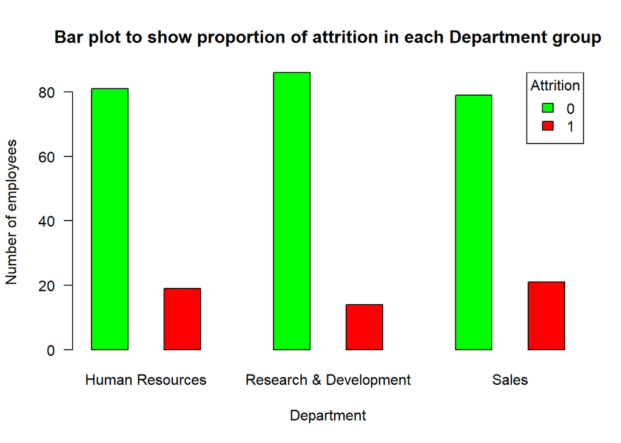

```r
barplot(round(prop.table(table(data$Attrition, data$Department), 2), 2) * 100,
        col = c("green", "red"), # used to indicate the colours we want
              # for each of the bars in the group
        beside = T,   # used to indicate when we want the bars to be besides each other in the groups
        main = "Bar plot to show proportion of attrition in each Department group",
        xlab = "Department",
        ylab = "Number of employees",
        las = 1,
        space = c(1,2), # specify number of spaces within and between groups of bars, used when
                #we want to add spaces between bars for clarity
        )

# use legend function to add more info to the bar plot (more useful than legend.text in barplot)
## new arguments explored: position, values, fill, title
legend("topright", # specify position where we want to add legend in the plot
       c("0", "1"), # specify values for which we want to add legend
       fill = c("green","red"), # specify colour we want to fill for
              # each corresponding legend value
       title = "Attrition" # specify the tile of the legend
       )
```

## We can see that attrition rate in Sales and HR is almost same (20%), but little less in case of R&D (14%).Supports hypothesis.

- *Hypothesis 4:*

### Education field of the employee: it denotes the field in which the employee studied, but this may not have

any impact on the attrition as each type of field comes with pros and cons, so attrition rate in each Education field is likely to be the same

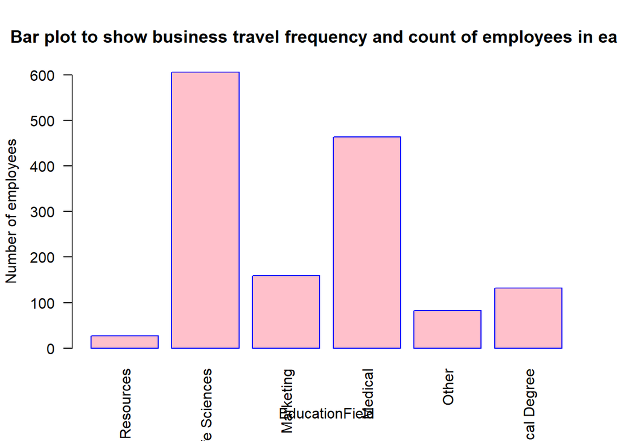

```r
barplot(table(data$EducationField ), # table used to get counts of each group
        main = "Bar plot to show business travel frequency and count of employees in each.", # Title we want
                # to give to the bar plot
        xlab = "EducationField", # Used to give label to the x axis
        ylab = "Number of employees", # Used to give label to the y axis
        col = "pink", # used to give colour to the bars for visual appeal
        border = 'blue', # used to denote border and outliers colour to distinguish and
        # visual appeal
        horiz = F, # boolean to denote whether we want the bars to be horizontal
        las = 2, # see both y-axis and x axis values horizontally, used when we want to see the
        # axes values clearly and avoid overlap with other values
        )
```

## Life sciences has most employees and HR has least

## This is a categorical column. So we can convert its type

```r
data$EducationField <- as.factor(data$EducationField)
```

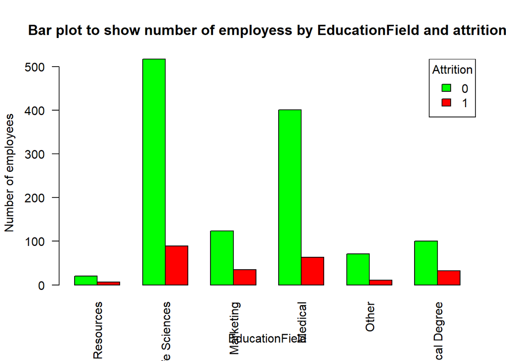

```r
barplot(table(data$Attrition, data$EducationField),
        col = c("green", "red"), # used to indicate the colours we want
              # for each of the bars in the group
        beside = T,   # used to indicate when we want the bars to be besides each other in the groups
        main = "Bar plot to show number of employess by EducationField and attrition",
        xlab = "EducationField",
        ylab = "Number of employees",
        las = 2,

        )

# use legend function to add more info to the bar plot (more useful than legend.text in barplot)
## new arguments explored: position, values, fill, title
legend("topright", # specify position where we want to add legend in the plot
       c("0", "1"), # specify values for which we want to add legend
       fill = c("green","red"), # specify colour we want to fill for
              # each corresponding legend value
       title = "Attrition" # specify the tile of the legend
       )
```

### We can see that highest count of attrition is in case of Life sciences and least in HR

### But we may need to get proportion of attriton in each group as the number of employees in each group is different

## Proportion table (Attrition | feature)

```r
round(prop.table(table(data$Attrition, data$EducationField), 2), 2) * 100
```

```
##
##     Human Resources Life Sciences Marketing Medical Other Technical Degree
##   0              74            85        78      86    87               76
##   1              26            15        22      14    13               24
```

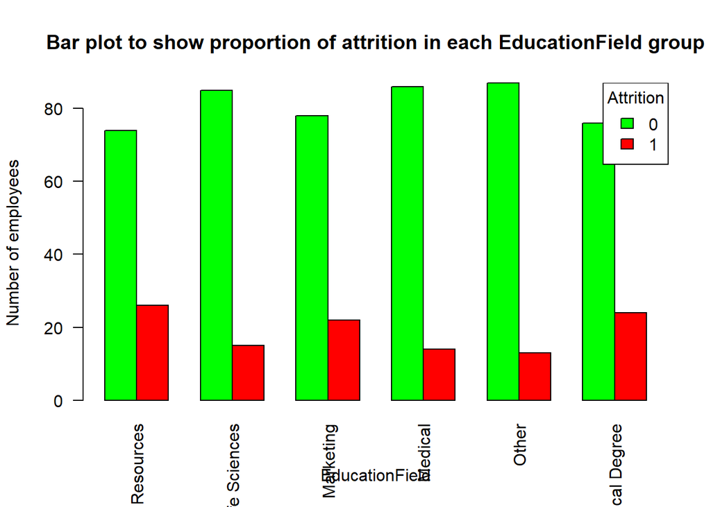

```r
barplot(round(prop.table(table(data$Attrition, data$EducationField), 2), 2) * 100,
        col = c("green", "red"), # used to indicate the colours we want
              # for each of the bars in the group
        beside = T,   # used to indicate when we want the bars to be besides each other in the groups
        main = "Bar plot to show proportion of attrition in each EducationField group",
        xlab = "EducationField",
        ylab = "Number of employees",
        las = 2,

        )

# use legend function to add more info to the bar plot (more useful than legend.text in barplot)
## new arguments explored: position, values, fill, title
legend("topright", # specify position where we want to add legend in the plot
       c("0", "1"), # specify values for which we want to add legend
       fill = c("green","red"), # specify colour we want to fill for
              # each corresponding legend value
       title = "Attrition" # specify the tile of the legend
       )
```

- *Hypothesis 5:*

### Environment satisfaction: This denotes the rating of the employee on how much he/she is satisfied with the workplace

environment. This can have a huge impact on attrition as, better work environment is more likely to keep the employee happy, so more the environment satisfaction, less likely the attrition

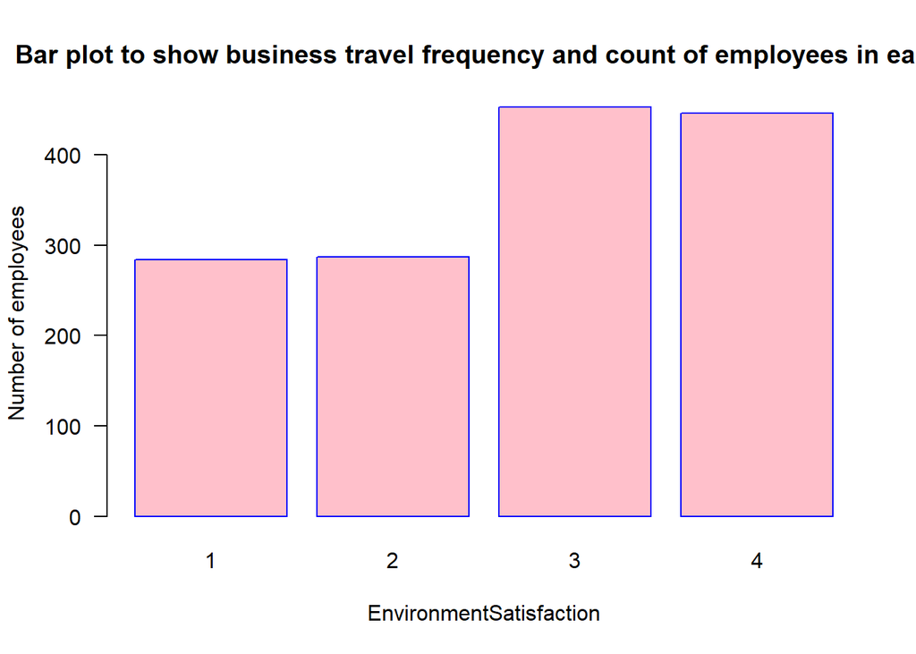

```r
barplot(table(data$EnvironmentSatisfaction ), # table used to get counts of each group
        main = "Bar plot to show business travel frequency and count of employees in each.", # Title we want
                # to give to the bar plot
        xlab = "EnvironmentSatisfaction", # Used to give label to the x axis
        ylab = "Number of employees", # Used to give label to the y axis
        col = "pink", # used to give colour to the bars for visual appeal
        border = 'blue', # used to denote border and outliers colour to distinguish and
        # visual appeal
        horiz = F, # boolean to denote whether we want the bars to be horizontal
        las = 1, # see both y-axis and x axis values horizontally, used when we want to see the
        # axes values clearly and avoid overlap with other values
        )
```

## Most employees have high env satisfaction

## This is a categorical column. So we can convert its type

```r
data$EnvironmentSatisfaction <- as.factor(data$EnvironmentSatisfaction)
```

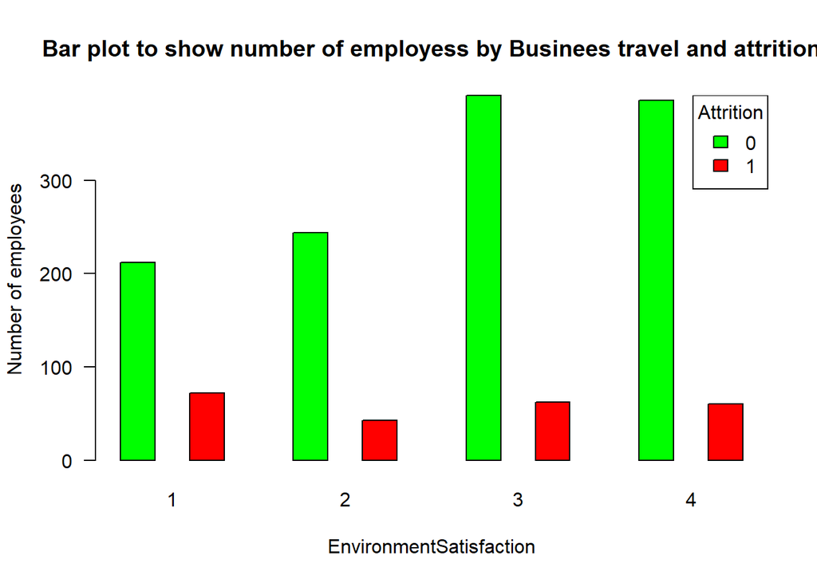

```r
barplot(table(data$Attrition, data$EnvironmentSatisfaction),
        col = c("green", "red"), # used to indicate the colours we want
              # for each of the bars in the group
        beside = T,   # used to indicate when we want the bars to be besides each other in the groups
        main = "Bar plot to show number of employess by Businees travel and attrition",
        xlab = "EnvironmentSatisfaction",
        ylab = "Number of employees",
        las = 1,
        space = c(1,2), # specify number of spaces within and between groups of bars, used when
                #we want to add spaces between bars for clarity
        )

# use legend function to add more info to the bar plot (more useful than legend.text in barplot)
## new arguments explored: position, values, fill, title
legend("topright", # specify position where we want to add legend in the plot
       c("0", "1"), # specify values for which we want to add legend
       fill = c("green","red"), # specify colour we want to fill for
              # each corresponding legend value
       title = "Attrition" # specify the tile of the legend
       )
```

### We can see that highest count of attrition is in case of 1 and least in 2

### But we may need to get proportion of attriton in each group as the number of employees in each group is different

## Proportion table (Attrition | feature)

```r
round(prop.table(table(data$Attrition, data$EnvironmentSatisfaction), 2), 2) * 100
```

```
##
##      1  2  3  4
##   0 75 85 86 87
##   1 25 15 14 13
```

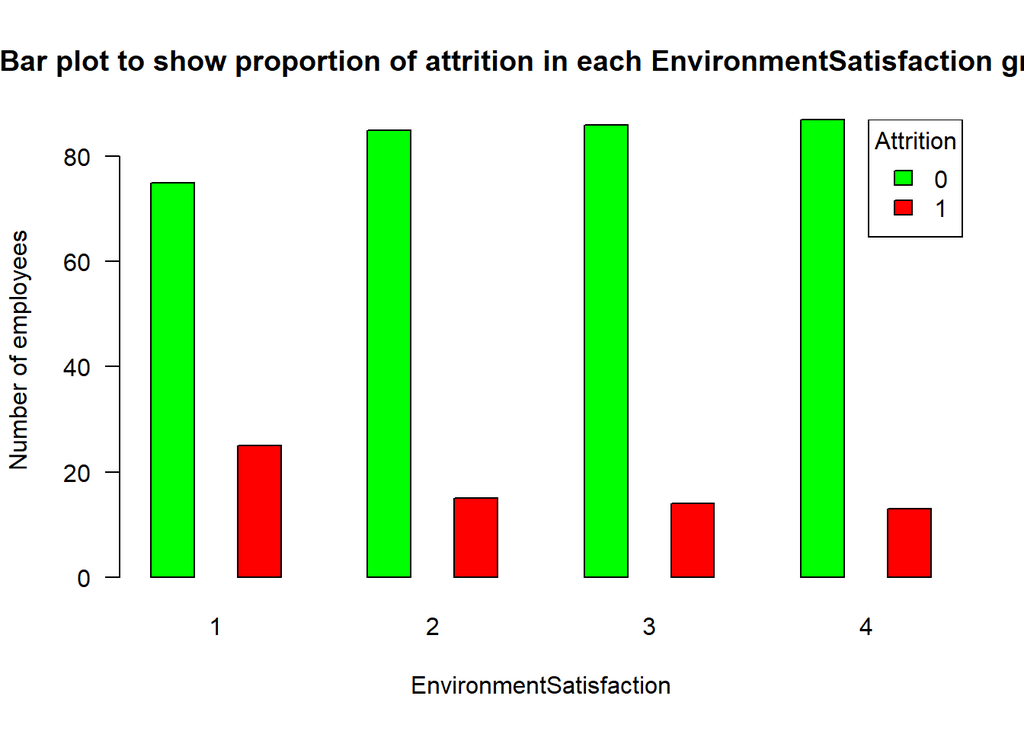

```r
barplot(round(prop.table(table(data$Attrition, data$EnvironmentSatisfaction), 2), 2) * 100,
        col = c("green", "red"), # used to indicate the colours we want
              # for each of the bars in the group
        beside = T,   # used to indicate when we want the bars to be besides each other in the groups
        main = "Bar plot to show proportion of attrition in each EnvironmentSatisfaction group",
        xlab = "EnvironmentSatisfaction",
        ylab = "Number of employees",
        las = 1,
        space = c(1,2), # specify number of spaces within and between groups of bars, used when
                #we want to add spaces between bars for clarity
        )

# use legend function to add more info to the bar plot (more useful than legend.text in barplot)
## new arguments explored: position, values, fill, title
legend("topright", # specify position where we want to add legend in the plot
       c("0", "1"), # specify values for which we want to add legend
       fill = c("green","red"), # specify colour we want to fill for
              # each corresponding legend value
       title = "Attrition" # specify the tile of the legend
       )
```

## We can see that as environment satisfaction increases attrition decreases, not huge impact though.Supports hypothesis.

- *Hypothesis 6:*

### Gender of the employee: Gender of the employee may signify differences in their lifestyle, etc. but in the workplace,

organizations are striving hard to maintain equality among all employees irrespective of gender, so gender may not have any impact on the attrition, so attrition rate in each gender is likely to be the same.

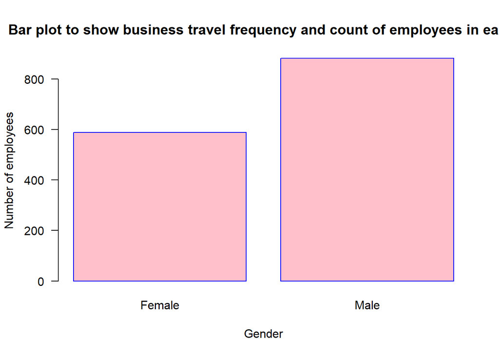

```r
barplot(table(data$Gender ), # table used to get counts of each group
        main = "Bar plot to show business travel frequency and count of employees in each.", # Title we want
                # to give to the bar plot
        xlab = "Gender", # Used to give label to the x axis
        ylab = "Number of employees", # Used to give label to the y axis
        col = "pink", # used to give colour to the bars for visual appeal
        border = 'blue', # used to denote border and outliers colour to distinguish and
        # visual appeal
        horiz = F, # boolean to denote whether we want the bars to be horizontal
        las = 1, # see both y-axis and x axis values horizontally, used when we want to see the
        # axes values clearly and avoid overlap with other values
        )
```

## Male employees count > female count

## This is a categorical column. So we can convert its type

```r
data$Gender <- as.factor(data$Gender)
```

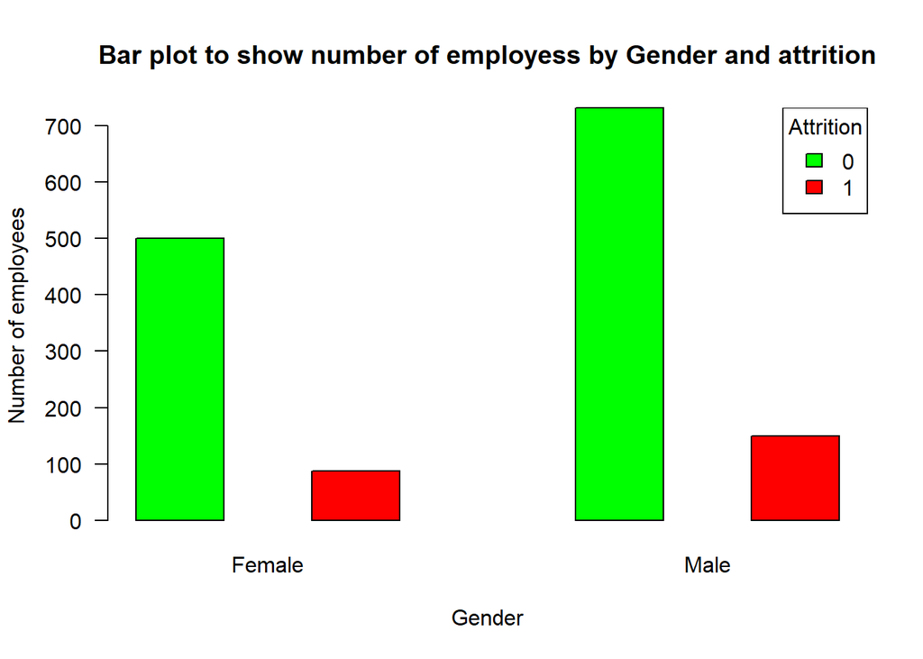

```r
barplot(table(data$Attrition, data$Gender),
        col = c("green", "red"), # used to indicate the colours we want
              # for each of the bars in the group
        beside = T,   # used to indicate when we want the bars to be besides each other in the groups
        main = "Bar plot to show number of employess by Gender and attrition",
        xlab = "Gender",
        ylab = "Number of employees",
        las = 1,
        space = c(1,2), # specify number of spaces within and between groups of bars, used when
                #we want to add spaces between bars for clarity
        )

# use legend function to add more info to the bar plot (more useful than legend.text in barplot)
## new arguments explored: position, values, fill, title
legend("topright", # specify position where we want to add legend in the plot
       c("0", "1"), # specify values for which we want to add legend
       fill = c("green","red"), # specify colour we want to fill for
              # each corresponding legend value
       title = "Attrition" # specify the tile of the legend
       )
```

### We can see that highest count of attrition is in case of male and least in female

### But we may need to get proportion of attriton in each group as the number of employees in each group is different

## Proportion table (Attrition | feature)

```r
round(prop.table(table(data$Attrition, data$Gender), 2), 2) * 100
```

```
##
##     Female Male
##   0     85   83
##   1     15   17
```

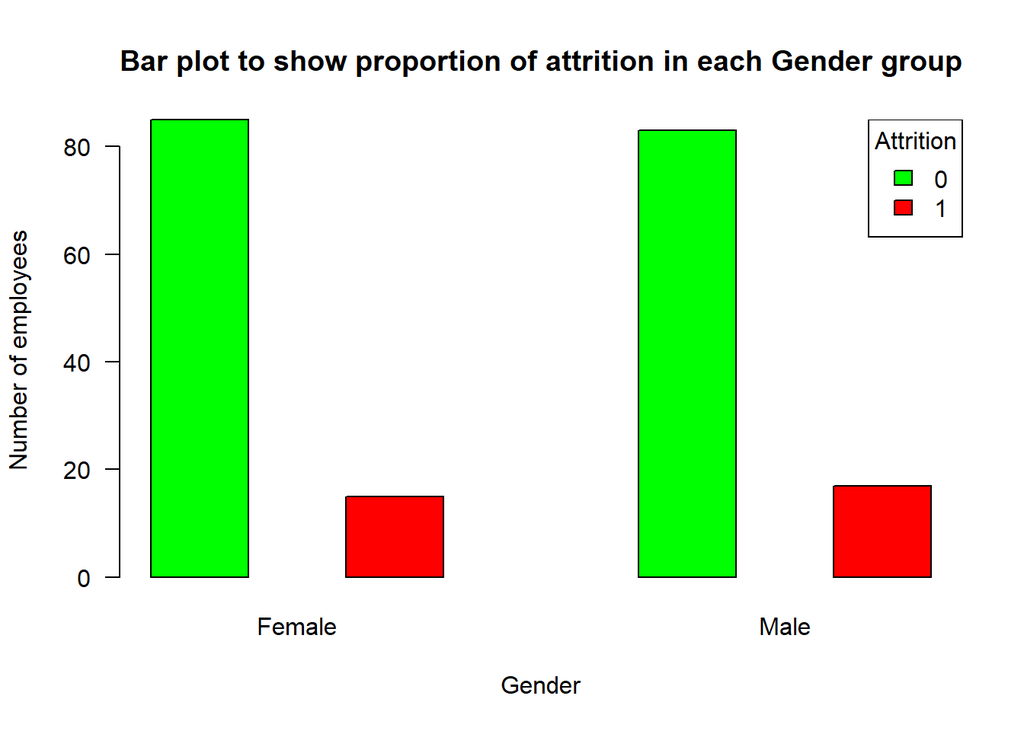

```r
barplot(round(prop.table(table(data$Attrition, data$Gender), 2), 2) * 100,
        col = c("green", "red"), # used to indicate the colours we want
              # for each of the bars in the group
        beside = T,   # used to indicate when we want the bars to be besides each other in the groups
        main = "Bar plot to show proportion of attrition in each Gender group",
        xlab = "Gender",
        ylab = "Number of employees",
        las = 1,
        space = c(1,2), # specify number of spaces within and between groups of bars, used when
                #we want to add spaces between bars for clarity
        )

# use legend function to add more info to the bar plot (more useful than legend.text in barplot)
## new arguments explored: position, values, fill, title
legend("topright", # specify position where we want to add legend in the plot
       c("0", "1"), # specify values for which we want to add legend
       fill = c("green","red"), # specify colour we want to fill for
              # each corresponding legend value
       title = "Attrition" # specify the tile of the legend
       )
```

## We can see that attrition rate is almost same for both genders. Supports hypothesis.

- *Hypothesis 7:* ### Job involvement: It is a rating of how involved the employee is in his job, can denote how much hands-on and involved the employee is in his job. Can’t affect attrition.

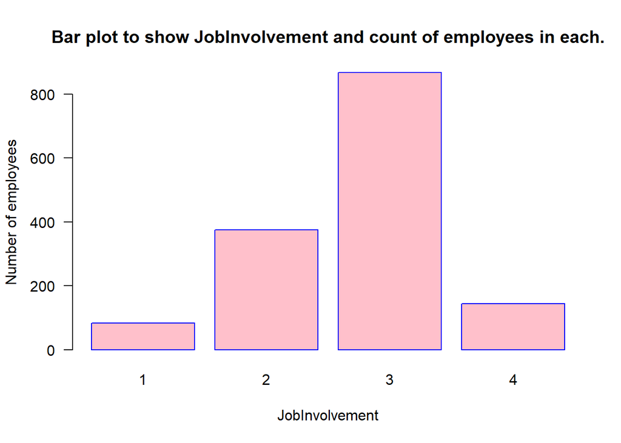

```r
barplot(table(data$JobInvolvement ), # table used to get counts of each group
        main = "Bar plot to show JobInvolvement and count of employees in each.", # Title we want
                # to give to the bar plot
        xlab = "JobInvolvement", # Used to give label to the x axis
        ylab = "Number of employees", # Used to give label to the y axis
        col = "pink", # used to give colour to the bars for visual appeal
        border = 'blue', # used to denote border and outliers colour to distinguish and
        # visual appeal
        horiz = F, # boolean to denote whether we want the bars to be horizontal
        las = 1, # see both y-axis and x axis values horizontally, used when we want to see the
        # axes values clearly and avoid overlap with other values
        )
```

## Highest employee count is in case of jobinvolvement rating 3.

## This is a categorical column. So we can convert its type

```r
data$JobInvolvement <- as.factor(data$JobInvolvement)
```

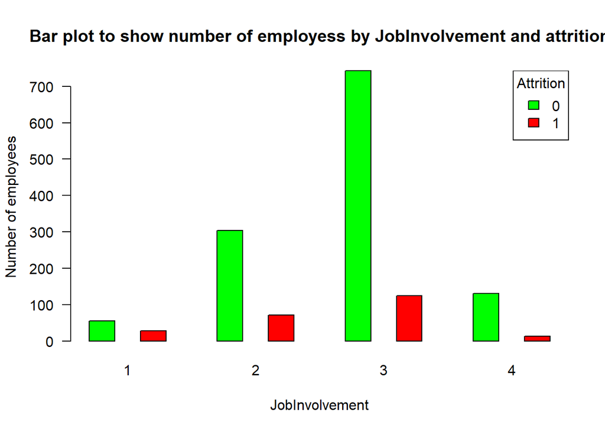

```r
barplot(table(data$Attrition, data$JobInvolvement),
        col = c("green", "red"), # used to indicate the colours we want
              # for each of the bars in the group
        beside = T,   # used to indicate when we want the bars to be besides each other in the groups
        main = "Bar plot to show number of employess by JobInvolvement and attrition",
        xlab = "JobInvolvement",
        ylab = "Number of employees",
        las = 1,
        space = c(1,2), # specify number of spaces within and between groups of bars, used when
                #we want to add spaces between bars for clarity
        )

# use legend function to add more info to the bar plot (more useful than legend.text in barplot)
## new arguments explored: position, values, fill, title
legend("topright", # specify position where we want to add legend in the plot
       c("0", "1"), # specify values for which we want to add legend
       fill = c("green","red"), # specify colour we want to fill for
              # each corresponding legend value
       title = "Attrition" # specify the tile of the legend
       )
```

### We can see that highest count of attrition is in case of 3 and least in 4 rating.

### But we may need to get proportion of attriton in each group as the number of employees in each group is different

## Proportion table (Attrition | feature)

```r
round(prop.table(table(data$Attrition, data$JobInvolvement), 2), 2) * 100
```

```
##
##      1  2  3  4
##   0 66 81 86 91
##   1 34 19 14  9
```

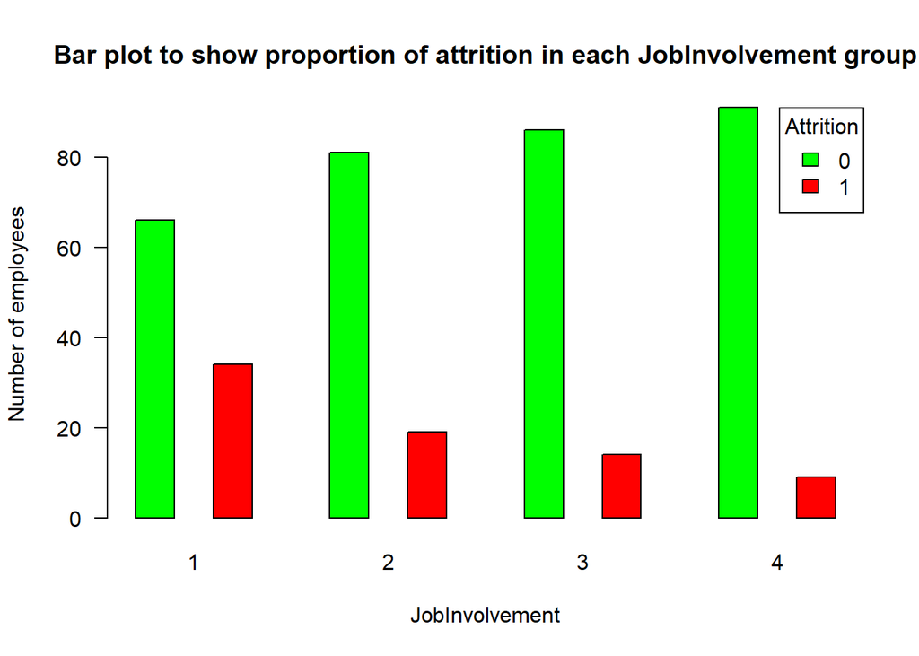

```r
barplot(round(prop.table(table(data$Attrition, data$JobInvolvement), 2), 2) * 100,
        col = c("green", "red"), # used to indicate the colours we want
              # for each of the bars in the group
        beside = T,   # used to indicate when we want the bars to be besides each other in the groups
        main = "Bar plot to show proportion of attrition in each JobInvolvement group",
        xlab = "JobInvolvement",
        ylab = "Number of employees",
        las = 1,
        space = c(1,2), # specify number of spaces within and between groups of bars, used when
                #we want to add spaces between bars for clarity
        )

# use legend function to add more info to the bar plot (more useful than legend.text in barplot)
## new arguments explored: position, values, fill, title
legend("topright", # specify position where we want to add legend in the plot
       c("0", "1"), # specify values for which we want to add legend
       fill = c("green","red"), # specify colour we want to fill for
              # each corresponding legend value
       title = "Attrition" # specify the tile of the legend
       )
```

## We can see that higher the JobInvolvement rating, lower the attrition rate. Rejects hypothesis.

- *Hypothesis 8:* ### Job level: It is a rating of how tough and hierarchy of the employee’s job. Tougher jobs can mean more pressure so higher the job level, more likely would be the attrition

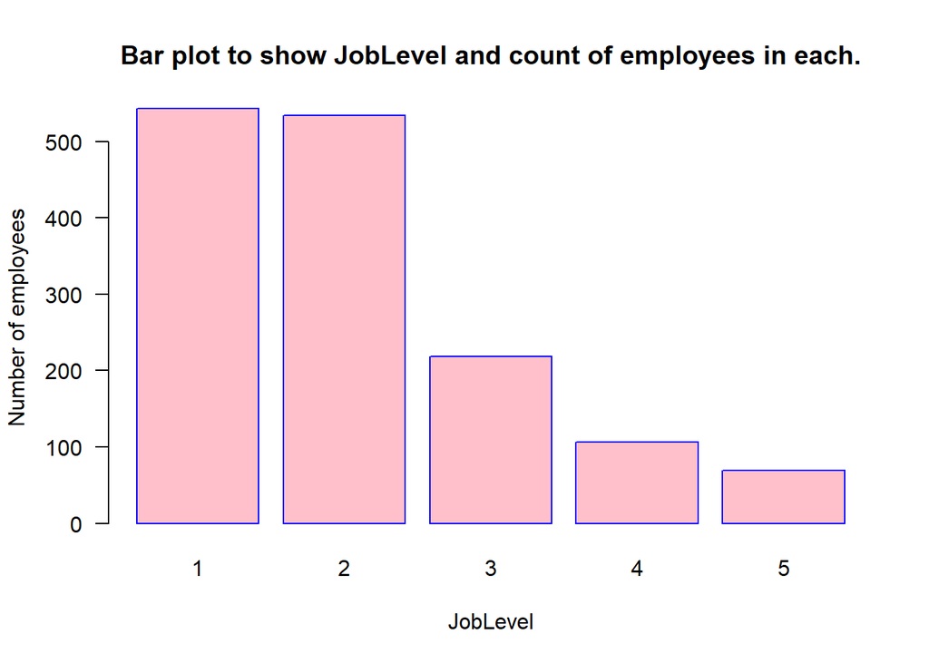

```r
barplot(table(data$JobLevel ), # table used to get counts of each group
        main = "Bar plot to show JobLevel and count of employees in each.", # Title we want
                # to give to the bar plot
        xlab = "JobLevel", # Used to give label to the x axis
        ylab = "Number of employees", # Used to give label to the y axis
        col = "pink", # used to give colour to the bars for visual appeal
        border = 'blue', # used to denote border and outliers colour to distinguish and
        # visual appeal
        horiz = F, # boolean to denote whether we want the bars to be horizontal
        las = 1, # see both y-axis and x axis values horizontally, used when we want to see the
        # axes values clearly and avoid overlap with other values
        )
```

## Most employees have job level 1,2

## This is a categorical column. So we can convert its type

```r
data$JobLevel <- as.factor(data$JobLevel)
```

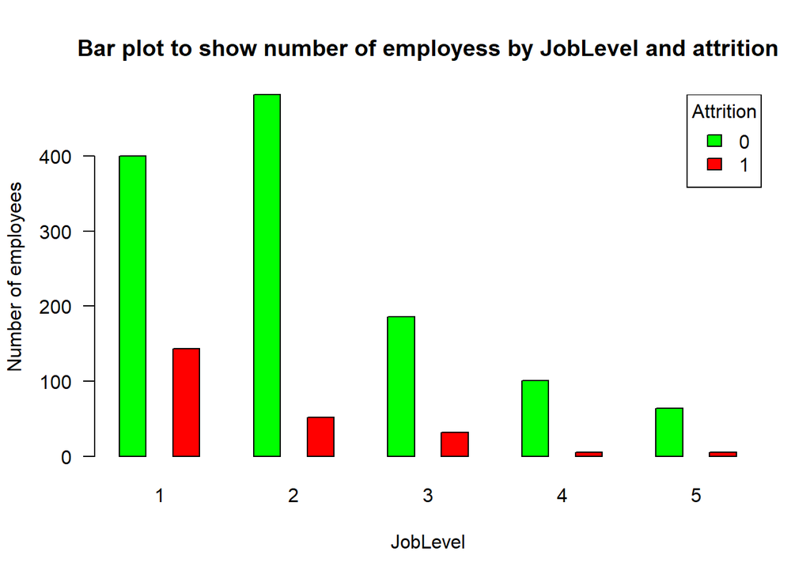

```r
barplot(table(data$Attrition, data$JobLevel),
        col = c("green", "red"), # used to indicate the colours we want
              # for each of the bars in the group
        beside = T,   # used to indicate when we want the bars to be besides each other in the groups
        main = "Bar plot to show number of employess by JobLevel and attrition",
        xlab = "JobLevel",
        ylab = "Number of employees",
        las = 1,
        space = c(1,2), # specify number of spaces within and between groups of bars, used when
                #we want to add spaces between bars for clarity
        )

# use legend function to add more info to the bar plot (more useful than legend.text in barplot)
## new arguments explored: position, values, fill, title
legend("topright", # specify position where we want to add legend in the plot
       c("0", "1"), # specify values for which we want to add legend
       fill = c("green","red"), # specify colour we want to fill for
              # each corresponding legend value
       title = "Attrition" # specify the tile of the legend
       )
```

### We can see that highest count of attrition is in case of 1 and least in 5 rating

### But we may need to get proportion of attriton in each group as the number of employees in each group is different

## Proportion table (Attrition | feature)

```r
round(prop.table(table(data$Attrition, data$JobLevel), 2), 2) * 100
```

```
##
##      1  2  3  4  5
##   0 74 90 85 95 93
##   1 26 10 15  5  7
```

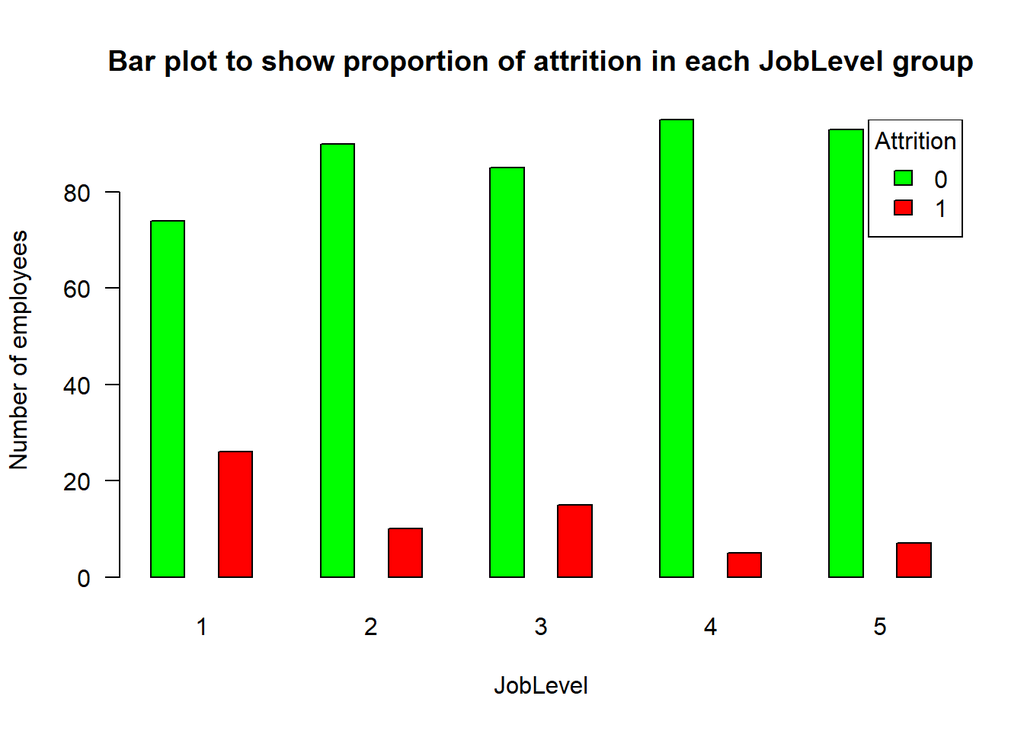

```r
barplot(round(prop.table(table(data$Attrition, data$JobLevel), 2), 2) * 100,
        col = c("green", "red"), # used to indicate the colours we want
              # for each of the bars in the group
        beside = T,   # used to indicate when we want the bars to be besides each other in the groups
        main = "Bar plot to show proportion of attrition in each JobLevel group",
        xlab = "JobLevel",
        ylab = "Number of employees",
        las = 1,
        space = c(1,2), # specify number of spaces within and between groups of bars, used when
                #we want to add spaces between bars for clarity
        )

# use legend function to add more info to the bar plot (more useful than legend.text in barplot)
## new arguments explored: position, values, fill, title
legend("topright", # specify position where we want to add legend in the plot
       c("0", "1"), # specify values for which we want to add legend
       fill = c("green","red"), # specify colour we want to fill for
              # each corresponding legend value
       title = "Attrition" # specify the tile of the legend
       )
```

## We can see that hthere is no trend in the attrition among Job level groups.Rejects hypothesis.

- *Hypothesis 9:* ### Job satisfaction: It is a rating of how satisfied the employee is in his job. It is most likely that higher the satisfaction, employee is lesser would be the attrition.

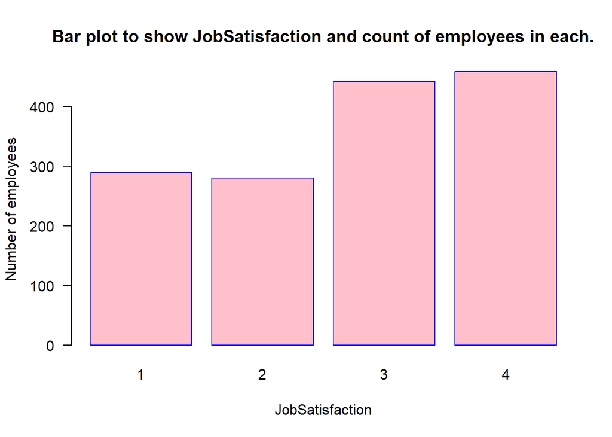

```r
barplot(table(data$JobSatisfaction ), # table used to get counts of each group
        main = "Bar plot to show JobSatisfaction and count of employees in each.", # Title we want
                # to give to the bar plot
        xlab = "JobSatisfaction", # Used to give label to the x axis
        ylab = "Number of employees", # Used to give label to the y axis
        col = "pink", # used to give colour to the bars for visual appeal
        border = 'blue', # used to denote border and outliers colour to distinguish and
        # visual appeal
        horiz = F, # boolean to denote whether we want the bars to be horizontal
        las = 1, # see both y-axis and x axis values horizontally, used when we want to see the
        # axes values clearly and avoid overlap with other values
        )
```

## More employes have higher job satisfaction

## This is a categorical column. So we can convert its type

```r
data$JobSatisfaction <- as.factor(data$JobSatisfaction)
```

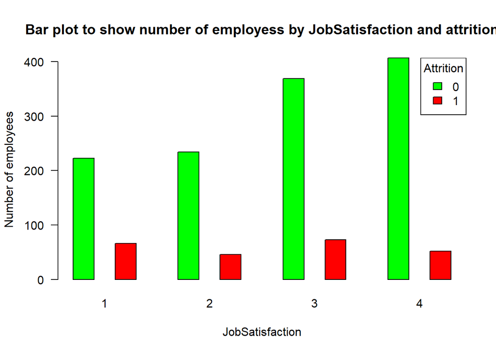

```r
barplot(table(data$Attrition, data$JobSatisfaction),
        col = c("green", "red"), # used to indicate the colours we want
              # for each of the bars in the group
        beside = T,   # used to indicate when we want the bars to be besides each other in the groups
        main = "Bar plot to show number of employess by JobSatisfaction and attrition",
        xlab = "JobSatisfaction",
        ylab = "Number of employees",
        las = 1,
        space = c(1,2), # specify number of spaces within and between groups of bars, used when
                #we want to add spaces between bars for clarity
        )

# use legend function to add more info to the bar plot (more useful than legend.text in barplot)
## new arguments explored: position, values, fill, title
legend("topright", # specify position where we want to add legend in the plot
       c("0", "1"), # specify values for which we want to add legend
       fill = c("green","red"), # specify colour we want to fill for
              # each corresponding legend value
       title = "Attrition" # specify the tile of the legend
       )
```

### We can see that highest count of attrition is highest in case of 3 and least in 2

### But we may need to get proportion of attriton in each group as the number of employees in each group is different

## Proportion table (Attrition | feature)

```r
round(prop.table(table(data$Attrition, data$JobSatisfaction), 2), 2) * 100
```

```
##
##      1  2  3  4
##   0 77 84 83 89
##   1 23 16 17 11
```

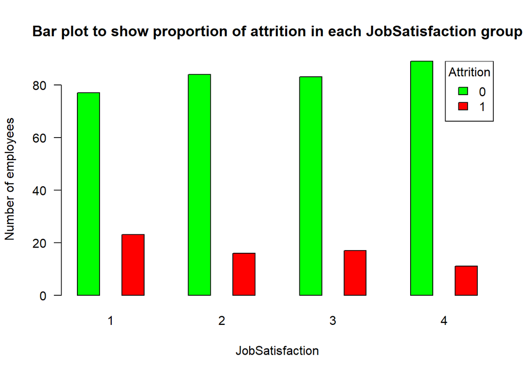

```r
barplot(round(prop.table(table(data$Attrition, data$JobSatisfaction), 2), 2) * 100,
        col = c("green", "red"), # used to indicate the colours we want
              # for each of the bars in the group
        beside = T,   # used to indicate when we want the bars to be besides each other in the groups
        main = "Bar plot to show proportion of attrition in each JobSatisfaction group",
        xlab = "JobSatisfaction",
        ylab = "Number of employees",
        las = 1,
        space = c(1,2), # specify number of spaces within and between groups of bars, used when
                #we want to add spaces between bars for clarity
        )

# use legend function to add more info to the bar plot (more useful than legend.text in barplot)
## new arguments explored: position, values, fill, title
legend("topright", # specify position where we want to add legend in the plot
       c("0", "1"), # specify values for which we want to add legend
       fill = c("green","red"), # specify colour we want to fill for
              # each corresponding legend value
       title = "Attrition" # specify the tile of the legend
       )
```

## We can see as higher job satisfaction, less is the attrition rate. Supports hypothesis.

```r
colnames(data)
```

```
##  [1] "Age"                     "Attrition"
##  [3] "BusinessTravel"          "Department"
##  [5] "EducationField"          "EnvironmentSatisfaction"
##  [7] "Gender"                  "JobInvolvement"
##  [9] "JobLevel"                "JobSatisfaction"
## [11] "MaritalStatus"           "MonthlyIncome"
## [13] "OverTime"                "TotalWorkingYears"
## [15] "WorkLifeBalance"         "YearsAtCompany"
## [17] "YearsInCurrentRole"      "YearsSinceLastPromotion"
## [19] "YearsWithCurrManager"    "DistanceFromHome"
```

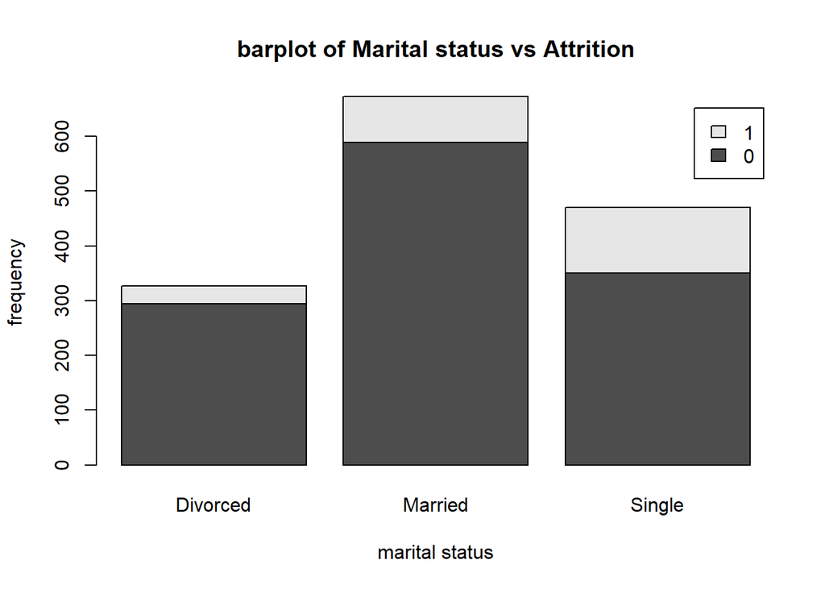

```r
# Hypothesis: Marital Status contributes to the attrition rate. Married & single categories might have more attrition rate.
# Null Hypothesis: Marital status does not have any affect on attrition.

# barplot to see the category-wise attrition rate.

barplot((table(data$Attrition,data$MaritalStatus)),legend.text = T,
        main = 'barplot of Marital status vs Attrition',
        ylab= 'frequency',
        xlab= 'marital status'
        )
```

Attrition rate(Attrition in a category/total number in that category) is observed to be high(120/470) for ‘single’.

```r
table(data$Attrition,data$MaritalStatus)
```

```
##
##     Divorced Married Single
##   0      294     589    350
##   1       33      84    120
```

```r
# Hypothesis: Monthly Income influences the attrition rate. Low income will have high attrition rate.
# Null Hypothesis: Monthly Income  does not have any affect on attrition.
```

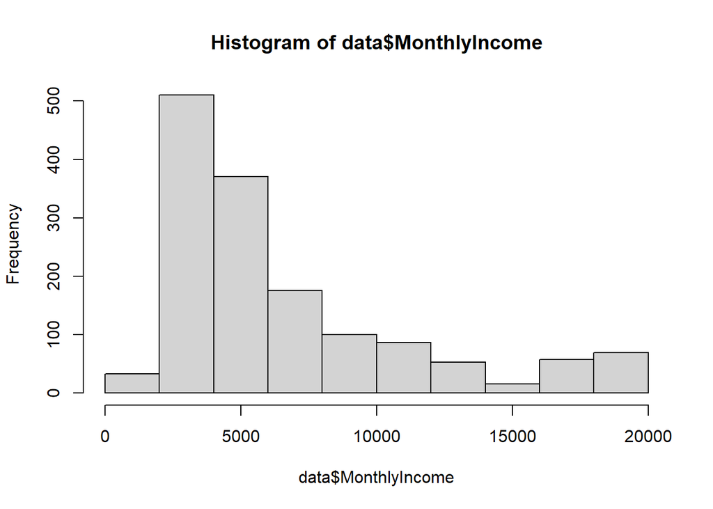

```r
## histogram of the monthly income
hist(data$MonthlyIncome)
```

the Monthly income is showing right skewed distribution.

```r
## creating a column 'monthlyincome bin' in the range (0,20000 with 2000 as bin size) to see
## the relation bewtween attrition vs income range.
data1 <- data
data1$MonthlyIncomebin <-cut(data1$MonthlyIncome,labels=c(1:10),
                            breaks = seq(0,20000,2000))
```

```r
# frequency of Attriction, non-attrition  vs incomebin
y = table(data1$Attrition, data1$MonthlyIncomebin)
y
```

```
##
##       1   2   3   4   5   6   7   8   9  10
##   0  15 391 329 157  85  72  47  16  57  64
##   1  18 119  42  18  15  14   6   0   0   5
```

```r
# % attrition  vs non-attrition - income bin wise
# table indicates the conditional probablity ie P(attrition status| the income-group).
round(prop.table(y, margin=2),2)*100
```

```
##
##       1   2   3   4   5   6   7   8   9  10
##   0  45  77  89  90  85  84  89 100 100  93
##   1  55  23  11  10  15  16  11   0   0   7
```

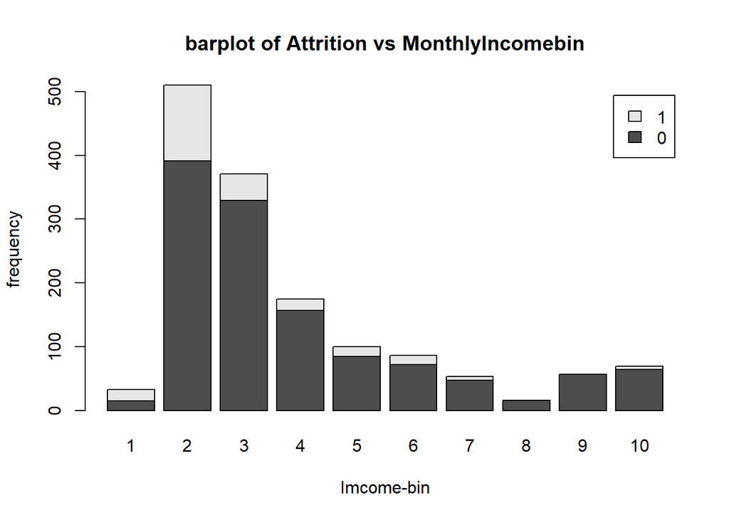

```r
# bar plot of the incomebin vs Attrition

barplot(table(data1$Attrition, data1$MonthlyIncomebin),
        legend.text = T,
        xlab= 'Imcome-bin',
        ylab='frequency',
        main= 'barplot of Attrition vs MonthlyIncomebin')
```

```r
# Hypothesis: Overtime leads to high attrition rate.
# Null Hypothesis: Overtime does not have any affect on attrition.

# proportion table for Attrition vs Overtime
round(prop.table(table(data$Attrition, data$OverTime), margin=2),2)*100
```

```
##
##     No Yes
##   0 90  69
##   1 10  31
```

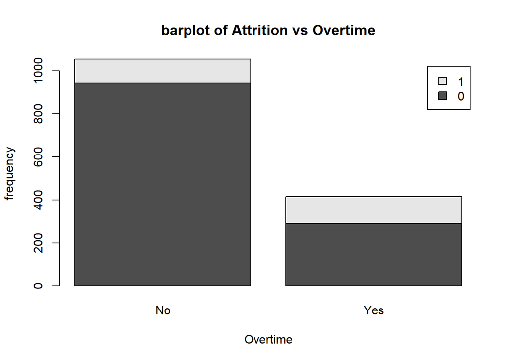

```r
# barplot of Attrition vs overtime

barplot(table(data$Attrition, data$OverTime),
        xlab = 'Overtime',
        ylab='frequency',
        legend.text = T,
        main= 'barplot of Attrition vs Overtime')
```

Plot/table indicates the proportion of people with Overtime=yes have high attrition rate.

```r
# table of the overtime category.
table(data$OverTime)
```

```
##
##   No  Yes
## 1054  416
```

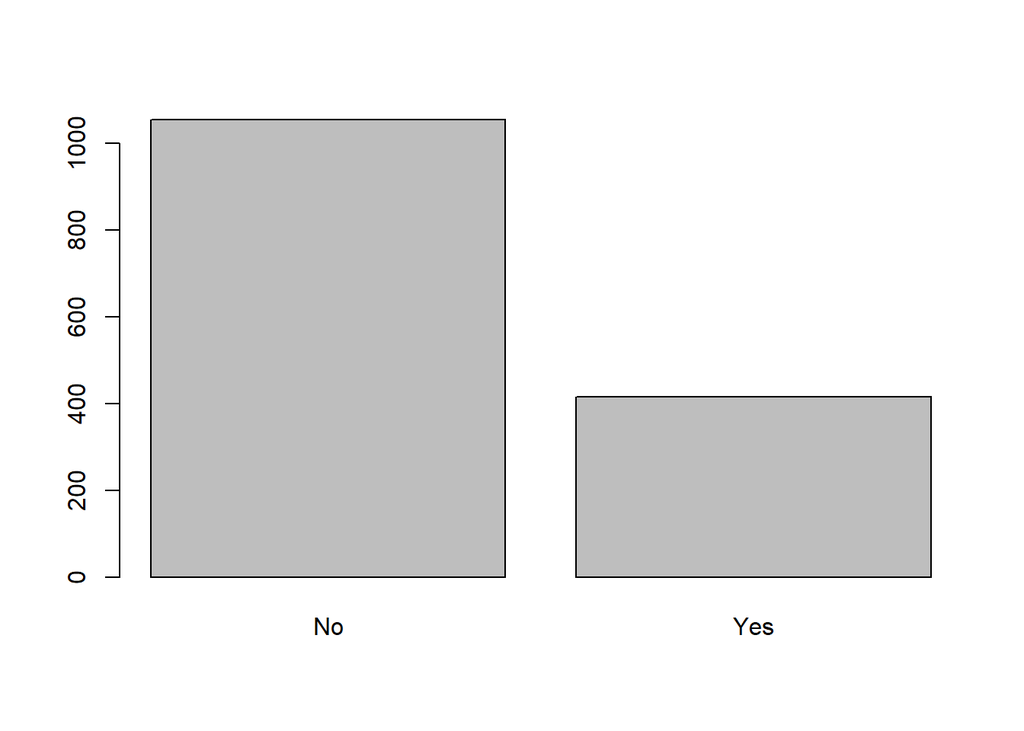

```r
# barplot of overtime
barplot(table(data$OverTime))
```

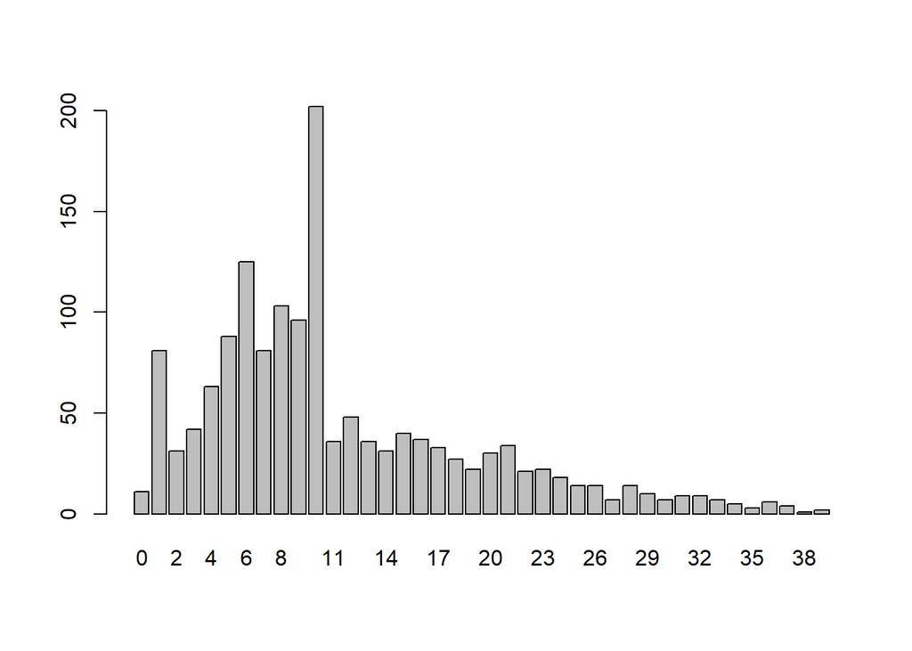

```r
# Hypothesis: Higher the Total Working years, lower the attrition rate.
# Null Hypothesis: Total Workign years does not have any affect on attrition.

#barplot of the Totalworking years variable.
barplot(table(data$TotalWorkingYears))
```

```r
## creating a column 'total working years bin' in the range (0,40 with 5 as bin size) to see
## the relation bewtween attrition vs Total working years.
data2 <- data
data2$TotalWorkingYearsbin <-cut(data$TotalWorkingYears,labels=seq(5,40,5),
                            breaks = seq(0,40,5))

# % attrition  vs non-attrition - Totalworkingyearsbin
# table indicates the conditional probablity ie P(attrition status| the working years bin).
round(prop.table(table(data2$Attrition,data2$TotalWorkingYearsbin), margin=2),2)*100
```

```
##
##      5 10 15 20 25 30 35 40
##   0 72 85 87 90 92 96 91 85
##   1 28 15 13 10  8  4  9 15
```

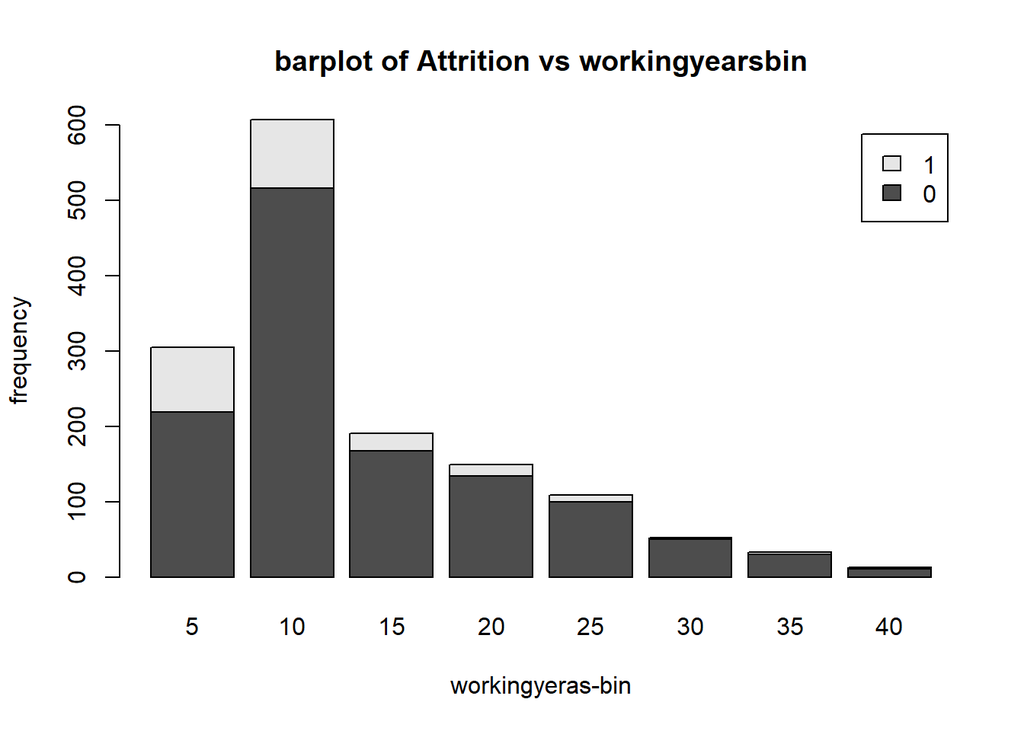

```r
# bar plot of the Totalworingyears vs Attrition
barplot(table(data2$Attrition, data2$TotalWorkingYearsbin),
        legend.text = T,
        xlab= 'workingyeras-bin',
        ylab='frequency',
        main= 'barplot of Attrition vs workingyearsbin')
```

The plot/table indicates that lower’totalworkingyears’(0-5 & 5-10 years groups) people gaving high attrition rate. However, one group of the highly experienced(higher total working years) people also have high attrition rate which is unexpected.This needs to be checked further wrt other variables.

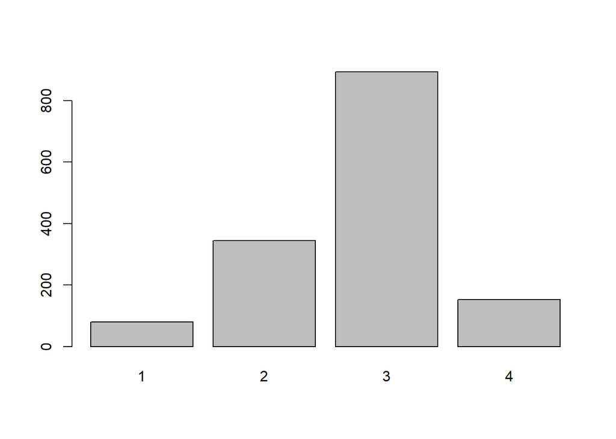

```r
# Hypothesis: Higher the Worklife Balance, lower the attrition rate.
# Null Hypothesis: Worklife balance does not have any affect on attrition.

barplot(table(data$WorkLifeBalance))
```

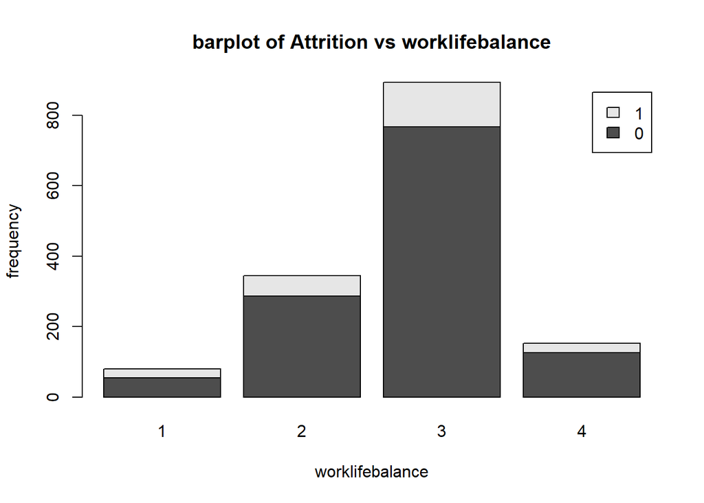

```r
barplot(table(data$Attrition, data$WorkLifeBalance),
        legend.text = T,
        xlab= 'worklifebalance',
        ylab='frequency',
        main= 'barplot of Attrition vs worklifebalance')
```

```r
# % attrition  vs non-attrition - worklife balance
# table indicates the conditional probablity ie P(attrition status| worklifebalance).
round(prop.table(table(data$Attrition,data$WorkLifeBalance), margin=2),2)
```

```
##
##        1    2    3    4
##   0 0.69 0.83 0.86 0.82
##   1 0.31 0.17 0.14 0.18
```

Plot/proportion table indicates lower work life balance(rating 1) with high attrition rate.

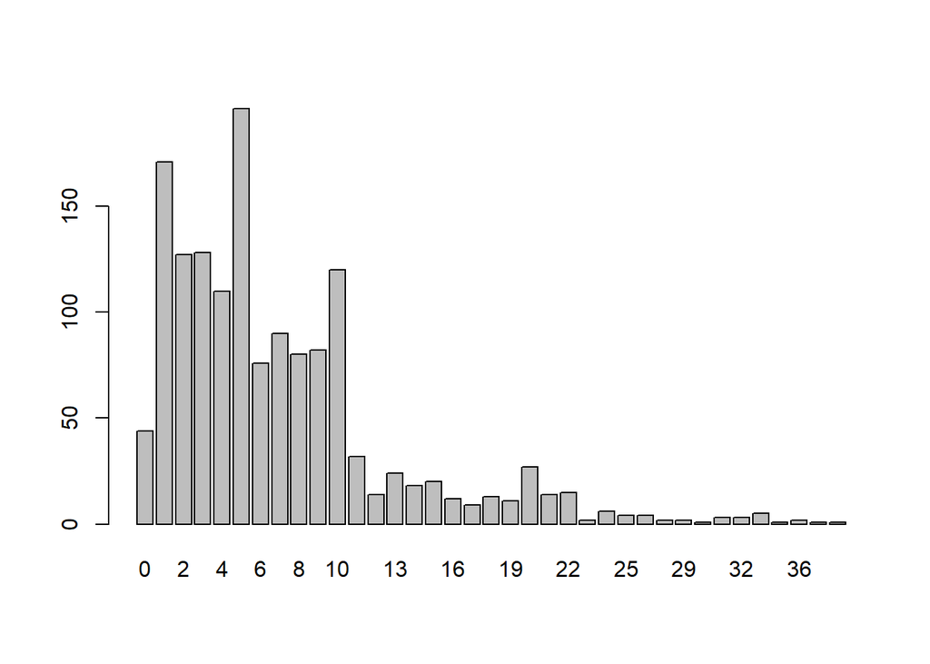

```r
#YearsAtCompany
# Hypothesis: Higher the YearsAtCompany, lower the attrition rate.
# Null Hypothesis: YearsAtCompan does not have any affect on attrition.

#barplot of the Totalworking years variable.
barplot(table(data$YearsAtCompany))
```

```r
## creating a column 'total working years bin' in the range (0,40 with 5 as bin size) to see
## the relation bewtween attrition vs Total working years.
data3 <- data
data3$YearsAtCompanybin <-cut(data$YearsAtCompany,labels=seq(5,40,5),
                            breaks = seq(0,40,5))

# % attrition  vs non-attrition - YearsAtCompanybin
# table indicates the conditional probablity ie P(attrition status| the YearsAtCompany bin).
round(prop.table(table(data3$Attrition,data3$YearsAtCompanybin), margin=2),2)*100
```

```
##
##       5  10  15  20  25  30  35  40
##   0  80  88  94  93  90 100  75  75
##   1  20  12   6   7  10   0  25  25
```

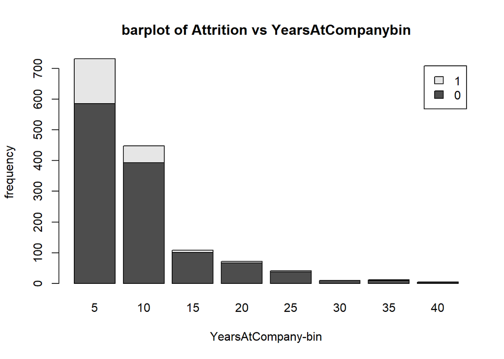

```r
# bar plot of the YearsAtCompany vs Attrition
barplot(table(data3$Attrition, data3$YearsAtCompanybin),
        legend.text = T,
        xlab= 'YearsAtCompany-bin',
        ylab='frequency',
        main= 'barplot of Attrition vs YearsAtCompanybin')
```

Plot/ proportins table indicate lower ‘YearsAtCompany’ with high attrition rate. The higher proportion of attrition rate at the highest rnage of ‘YearsAtCompany’ may be due to less number of employees.

```r
max(data$YearsSinceLastPromotion)
```

```
## [1] 15
```

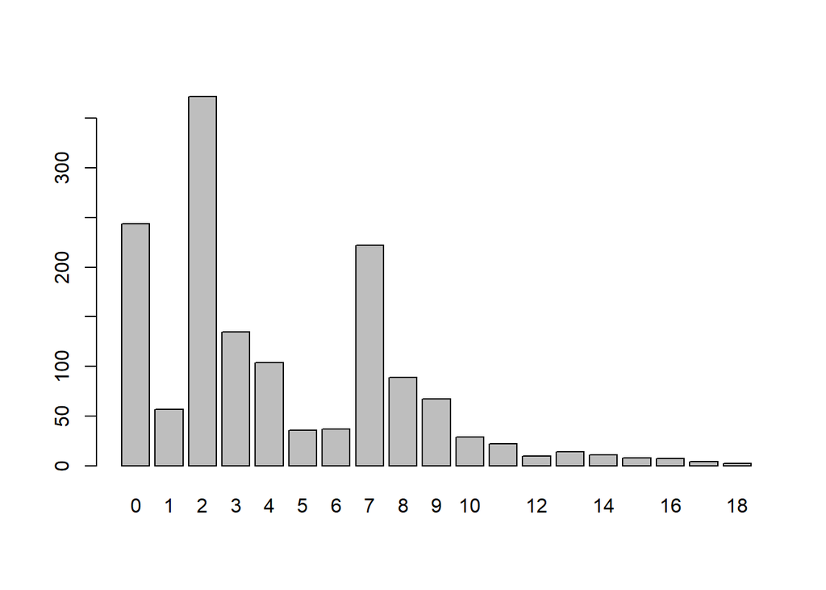

```r
 #YearsInCurrentRole
# Hypothesis: Higher the YearsInCurrentRole, higher the attrition rate.
# Null Hypothesis: YearsInCurrentRol does not have any affect on attrition.

#barplot of the YearsInCurrentRole variable.
barplot(table(data$YearsInCurrentRole))
```

```r
## creating a column 'YearsInCurrentRole bin' in the range (0,18 with 6 as bin size) to see
## the relation bewtween attrition vs YearsInCurrentRole.
data4 <- data
data4$YearsInCurrentRolebin <-cut(data$YearsInCurrentRole,labels=seq(6,18,6),
                            breaks = seq(0,18,6))

# % attrition  vs non-attrition - YearsInCurrentRolebin
# table indicates the conditional probablity ie P(attrition status| the YearsInCurrentRole bin).
round(prop.table(table(data4$Attrition,data4$YearsInCurrentRolebin), margin=2),2)*100
```

```
##
##      6 12 18
##   0 85 89 91
##   1 15 11  9
```

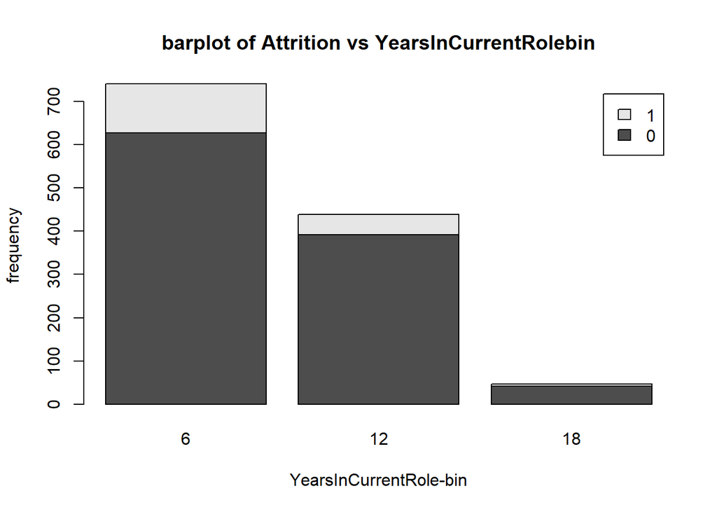

```r
# bar plot of the YearsAtCompany vs Attrition
barplot(table(data4$Attrition, data4$YearsInCurrentRolebin),
        legend.text = T,
        xlab= 'YearsInCurrentRole-bin',
        ylab='frequency',
        main= 'barplot of Attrition vs YearsInCurrentRolebin')
```

The plot as well the proptions table indicate ‘lower YearsInCurrentRole’ with higher attrition rate. which is aginst the null hypothesis. Other varibales to be checked to conclude further.

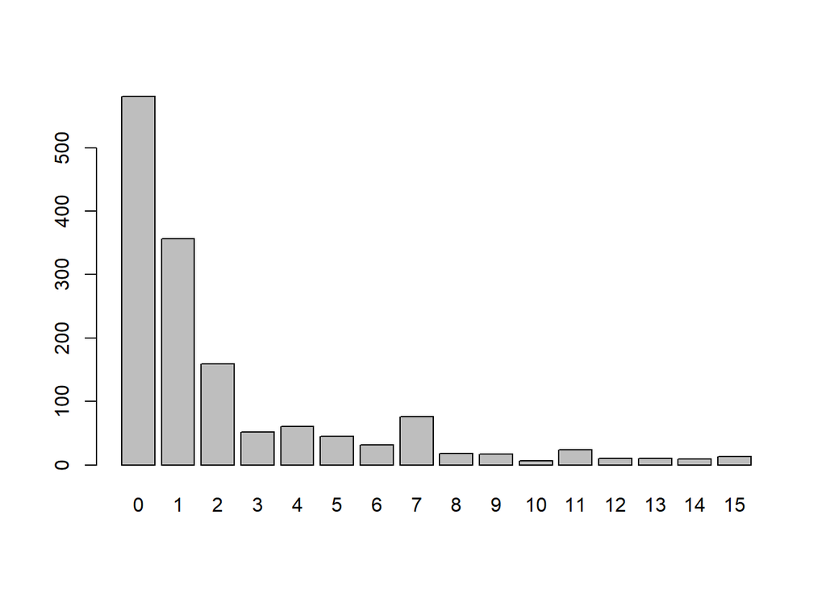

```r
#YearsSinceLastPromotion

 #YearsSinceLastPromotion
# Hypothesis: Higher the YearsSinceLastPromotion, higher the attrition rate.
# Null Hypothesis: YearsSinceLastPromotio does not have any affect on attrition.

#barplot of the YearsSinceLastPromotion variable.
barplot(table(data$YearsSinceLastPromotion))
```

```r
## creating a column 'YearsSinceLastPromotion bin' in the range (0,15 with 3 as bin size) to see
## the relation bewtween attrition vs YearsSinceLastPromotion.
data5 <- data
data5$YearsSinceLastPromotionbin <-cut(data$YearsSinceLastPromotion,labels=seq(3,15,3),
                            breaks = seq(0,15,3))

# % attrition  vs non-attrition - YearsSinceLastPromotionbin
# table indicates the conditional probablity ie P(attrition status| the YearsSinceLastPromotion bin).
round(prop.table(table(data5$Attrition,data5$YearsSinceLastPromotionbin), margin=2),2)*100
```

```
##
##      3  6  9 12 15
##   0 85 91 82 92 81
##   1 15  9 18  7 19
```

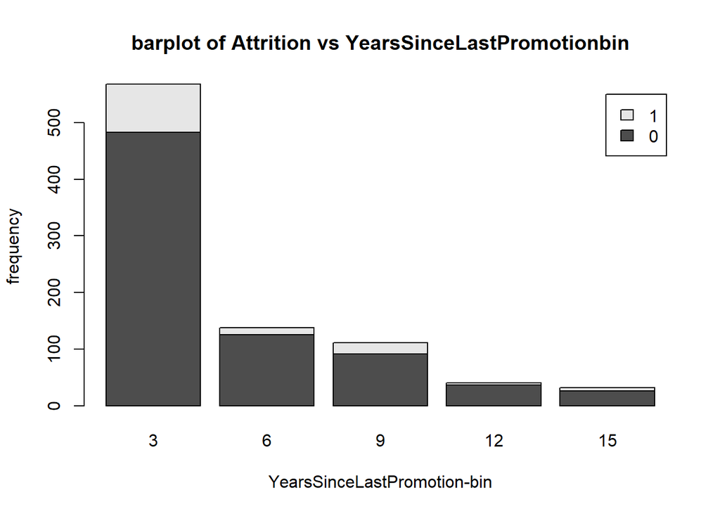

```r
# bar plot of the YearsAtCompany vs Attrition
barplot(table(data5$Attrition, data5$YearsSinceLastPromotionbin),
        legend.text = T,
        xlab= 'YearsSinceLastPromotion-bin',
        ylab='frequency',
        main= 'barplot of Attrition vs YearsSinceLastPromotionbin')
```

Plot/ table of proportion do not indicate proper relation of ‘yearssince lastpromotion’ wrt Attrition.

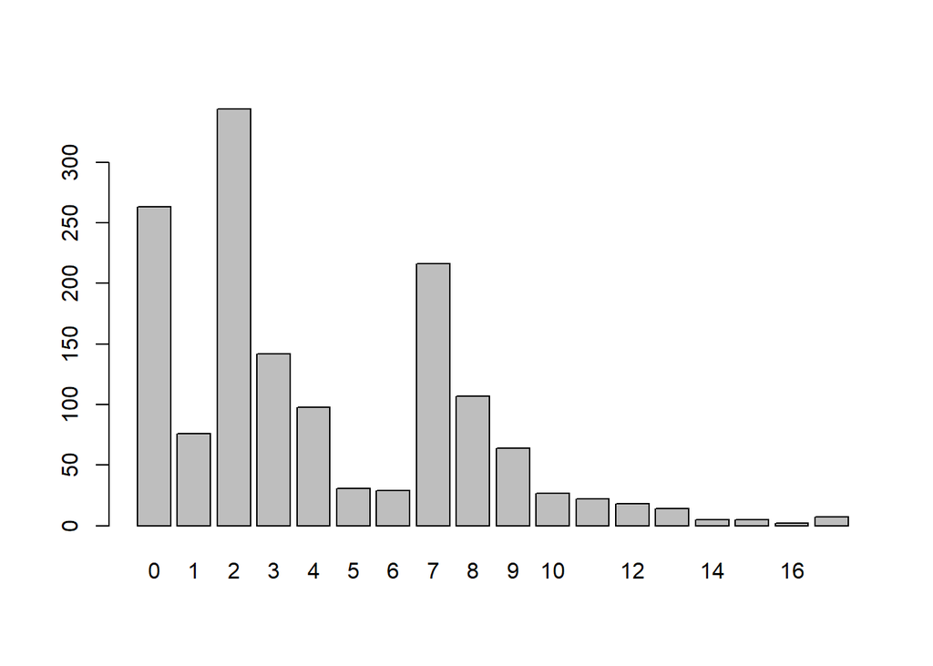

```r
 #YearsWithCurrManager
# Hypothesis: Higher the YearsWithCurrManager, higher the attrition rate.
# Null Hypothesis:  YearsWithCurrManage does not have any affect on attrition.

#barplot of the YearsWithCurrManager variable.
barplot(table(data$YearsWithCurrManager))
```

```r
## creating a column 'YearsWithCurrManager bin' in the range (0,18 with 3 as bin size) to see
## the relation bewtween attrition vs YearsWithCurrManager.
data6 <- data
data6$YearsWithCurrManagerbin <-cut(data$YearsWithCurrManager,labels=seq(3,18,3),
                            breaks = seq(0,18,3))

# % attrition  vs non-attrition - YearsWithCurrManagerbin
# table indicates the conditional probablity ie P(attrition status| the YearsWithCurrManager bin).
round(prop.table(table(data6$Attrition,data6$YearsWithCurrManagerbin), margin=2),2)*100
```

```
##
##       3   6   9  12  15  18
##   0  86  88  88  94  92 100
##   1  14  12  12   6   8   0
```

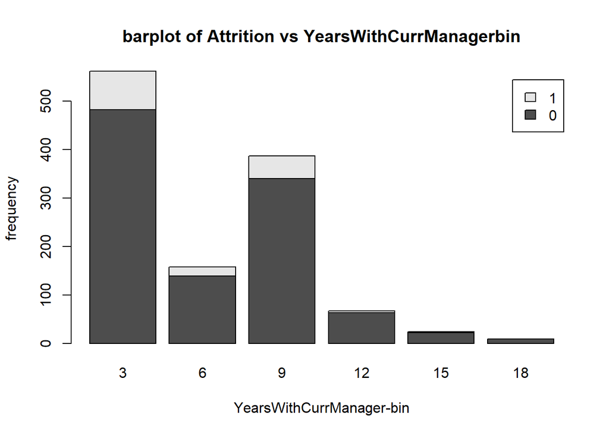

```r
# bar plot of the YearsAtCompany vs Attrition
barplot(table(data6$Attrition, data6$YearsWithCurrManagerbin),
        legend.text = T,
        xlab= 'YearsWithCurrManager-bin',
        ylab='frequency',
        main= 'barplot of Attrition vs YearsWithCurrManagerbin')
```

The plot & proportions table indicate lower ‘yearswithcurrmanager’ having higher attrition rate whcih needs to looked into.

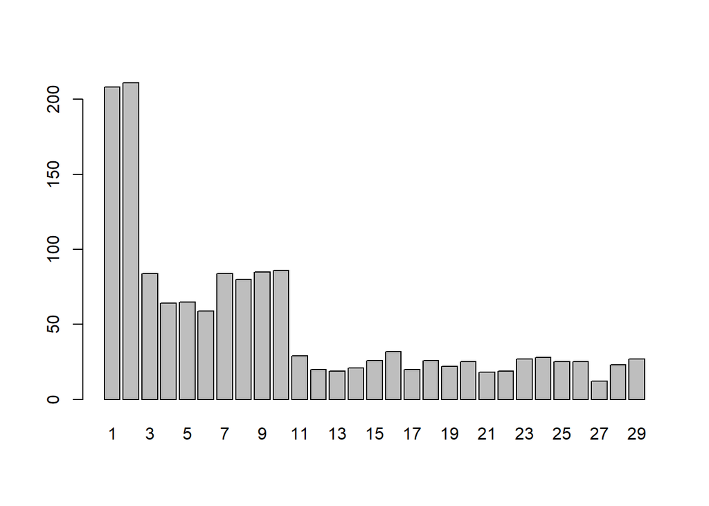

```r
 # DistanceFromHome
#DistanceFromHome
# Hypothesis: Higher the DistanceFromHome, higher the attrition rate.
# Null Hypothesis:  Distancefromhome does not have any affect on attrition.

#barplot of the DistanceFromHome variable.
barplot(table(data$DistanceFromHome))
```

```r
## creating a column 'DistanceFromHome bin' in the range (0,30 with 3 as bin size) to see
## the relation bewtween attrition vs DistanceFromHome.
data7 <- data
data7$DistanceFromHomebin <-cut(data$DistanceFromHome,labels=seq(10,30,10),
                            breaks = seq(0,30,10))

# % attrition  vs non-attrition - DistanceFromHomebin
# table indicates the conditional probablity ie P(attrition status| the DistanceFromHome bin).
round(prop.table(table(data7$Attrition,data7$DistanceFromHomebin), margin=2),2)*100
```

```
##
##     10 20 30
##   0 86 80 78
##   1 14 20 22
```

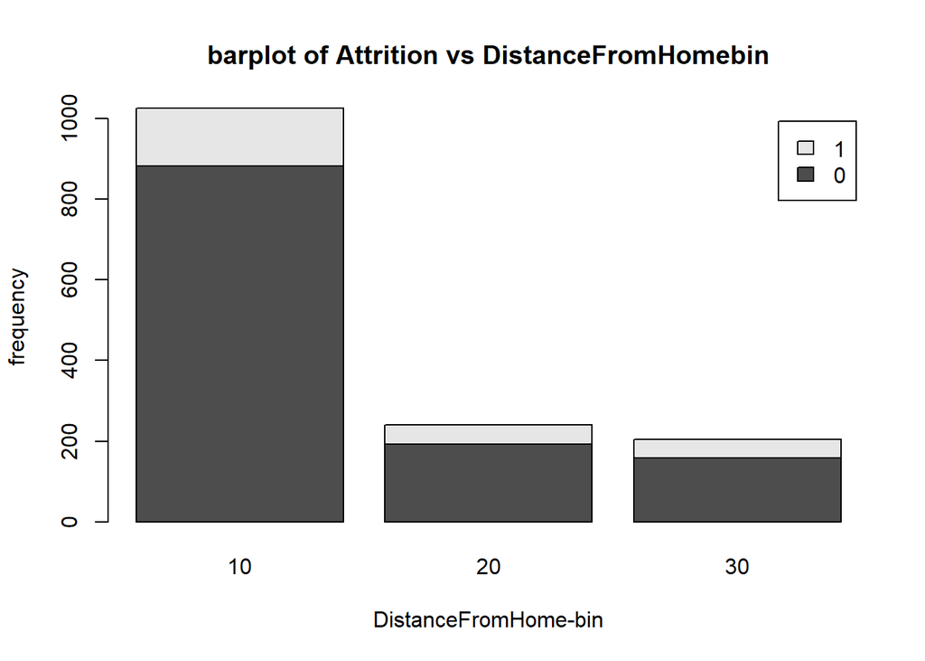

```r
# bar plot of the YearsAtCompany vs Attrition
barplot(table(data7$Attrition, data7$DistanceFromHomebin),
        legend.text = T,
        xlab= 'DistanceFromHome-bin',
        ylab='frequency',
        main= 'barplot of Attrition vs DistanceFromHomebin')
```

###The plot and proptions table indicate higher ‘distancefromhome’ to higher attrition rate.

# Concluding note: Job satisfaction, Age, Business travel, environment satisfaction, Job satisfaction, Job involvement, Maritastatus, monthly income, overtime, worklife balance, yearsatcompany , distance from home, are likely to have impact on the attrition rate